# ANCOVA in Vocabulario Não Ensinado (Vocabulario Não Ensinado)

Geiser C. Challco geiser@alumni.usp.br

- Descriptive Statistics of Initial Data
- ANCOVA and Pairwise for one factor: **grupo**
  - Without remove non-normal data
  - Computing ANCOVA and PairWise After removing non-normal data (OK)
    - Plots for ancova
    - Checking linearity assumption
    - Checking normality and homogeneity
- ANCOVA and Pairwise for two factors **grupo:Sexo**
  - Without remove non-normal data
  - Computing ANCOVA and PairWise After removing non-normal data (OK)
    - Plots for ancova
    - Checking linearity assumption
    - Checking normality and homogeneity
- ANCOVA and Pairwise for two factors **grupo:Zona**
  - Without remove non-normal data
  - Computing ANCOVA and PairWise After removing non-normal data (OK)
    - Plots for ancova
    - Checking linearity assumption
    - Checking normality and homogeneity
- ANCOVA and Pairwise for two factors **grupo:Cor.Raca**
  - Without remove non-normal data
  - Computing ANCOVA and PairWise After removing non-normal data (OK)
    - Plots for ancova
    - Checking linearity assumption
    - Checking normality and homogeneity
- ANCOVA and Pairwise for two factors **grupo:Serie**
  - Without remove non-normal data
  - Computing ANCOVA and PairWise After removing non-normal data (OK)
    - Plots for ancova
    - Checking linearity assumption
    - Checking normality and homogeneity
- Summary of Results
  - Descriptive Statistics
  - ANCOVA Table Comparison
  - PairWise Table Comparison
  - EMMS Table Comparison

**NOTE**:

- Teste ANCOVA para determinar se houve diferenças significativas no Vocabulario Não Ensinado (medido usando pre- e pos-testes).
- ANCOVA test to determine whether there were significant differences in Vocabulario Não Ensinado (measured using pre- and post-tests).

# Descriptive Statistics of Initial Data

```r
df <- get.descriptives(dat, c(dv.pre, dv.pos), c("grupo"),
                       include.global = T, symmetry.test = T, normality.test = F)
df <- plyr::rbind.fill(
  df, do.call(plyr::rbind.fill, lapply(lfatores2, FUN = function(f) {
    if (nrow(dat) > 0 && sum(!is.na(unique(dat[[f]]))) > 1)
      get.descriptives(dat, c(dv.pre,dv.pos), c("grupo", f),
                       symmetry.test = T, normality.test = F)
    }))
)
(df <- df[,c(fatores1[fatores1 %in% colnames(df)],"variable",
             colnames(df)[!colnames(df) %in% c(fatores1,"variable")])])
```

```
##           grupo Sexo   Zona Cor.Raca Serie            variable   n   mean median min max    sd    se
## 1      Controle <NA>   <NA>     <NA>  <NA> vocab.non.teach.pre 110 22.182   22.0  20  24 1.441 0.137
## 2  Experimental <NA>   <NA>     <NA>  <NA> vocab.non.teach.pre 167 21.988   22.0  20  24 1.439 0.111
## 3          <NA> <NA>   <NA>     <NA>  <NA> vocab.non.teach.pre 277 22.065   22.0  20  24 1.441 0.087
## 4      Controle <NA>   <NA>     <NA>  <NA> vocab.non.teach.pos 110 23.345   24.0   7  35 5.178 0.494
## 5  Experimental <NA>   <NA>     <NA>  <NA> vocab.non.teach.pos 167 22.940   23.0   2  35 5.527 0.428
## 6          <NA> <NA>   <NA>     <NA>  <NA> vocab.non.teach.pos 277 23.101   24.0   2  35 5.386 0.324
## 7      Controle    F   <NA>     <NA>  <NA> vocab.non.teach.pre  65 22.138   22.0  20  24 1.467 0.182
## 8      Controle    M   <NA>     <NA>  <NA> vocab.non.teach.pre  45 22.244   22.0  20  24 1.417 0.211
## 9  Experimental    F   <NA>     <NA>  <NA> vocab.non.teach.pre  90 21.956   22.0  20  24 1.398 0.147
## 10 Experimental    M   <NA>     <NA>  <NA> vocab.non.teach.pre  77 22.026   22.0  20  24 1.495 0.170
## 11     Controle    F   <NA>     <NA>  <NA> vocab.non.teach.pos  65 23.877   24.0   7  35 5.272 0.654
## 12     Controle    M   <NA>     <NA>  <NA> vocab.non.teach.pos  45 22.578   23.0  10  33 4.998 0.745
## 13 Experimental    F   <NA>     <NA>  <NA> vocab.non.teach.pos  90 23.211   23.0   6  34 5.276 0.556
## 14 Experimental    M   <NA>     <NA>  <NA> vocab.non.teach.pos  77 22.623   23.0   2  35 5.827 0.664
```

[output cut: 98 more lines]

| grupo | Sexo | Zona | Cor.Raca | Serie | variable | n | mean | median | min | max | sd | se | ci | iqr | symmetry | skewness | kurtosis |
| --- | --- | --- | --- | --- | --- | --- | --- | --- | --- | --- | --- | --- | --- | --- | --- | --- | --- |
| Controle |  |  |  |  | vocab.non.teach.pre | 110 | 22.182 | 22.0 | 20 | 24 | 1.441 | 0.137 | 0.272 | 3.00 | YES | -0.134 | -1.328 |
| Experimental |  |  |  |  | vocab.non.teach.pre | 167 | 21.988 | 22.0 | 20 | 24 | 1.439 | 0.111 | 0.220 | 2.00 | YES | -0.039 | -1.401 |
|  |  |  |  |  | vocab.non.teach.pre | 277 | 22.065 | 22.0 | 20 | 24 | 1.441 | 0.087 | 0.170 | 2.00 | YES | -0.077 | -1.361 |
| Controle |  |  |  |  | vocab.non.teach.pos | 110 | 23.345 | 24.0 | 7 | 35 | 5.178 | 0.494 | 0.979 | 5.00 | YES | -0.485 | 0.942 |
| Experimental |  |  |  |  | vocab.non.teach.pos | 167 | 22.940 | 23.0 | 2 | 35 | 5.527 | 0.428 | 0.844 | 7.00 | NO | -0.671 | 0.781 |
|  |  |  |  |  | vocab.non.teach.pos | 277 | 23.101 | 24.0 | 2 | 35 | 5.386 | 0.324 | 0.637 | 6.00 | NO | -0.616 | 0.896 |
| Controle | F |  |  |  | vocab.non.teach.pre | 65 | 22.138 | 22.0 | 20 | 24 | 1.467 | 0.182 | 0.364 | 3.00 | YES | -0.060 | -1.373 |
| Controle | M |  |  |  | vocab.non.teach.pre | 45 | 22.244 | 22.0 | 20 | 24 | 1.417 | 0.211 | 0.426 | 2.00 | YES | -0.238 | -1.318 |
| Experimental | F |  |  |  | vocab.non.teach.pre | 90 | 21.956 | 22.0 | 20 | 24 | 1.398 | 0.147 | 0.293 | 2.00 | YES | -0.044 | -1.351 |
| Experimental | M |  |  |  | vocab.non.teach.pre | 77 | 22.026 | 22.0 | 20 | 24 | 1.495 | 0.170 | 0.339 | 2.00 | YES | -0.044 | -1.498 |
| Controle | F |  |  |  | vocab.non.teach.pos | 65 | 23.877 | 24.0 | 7 | 35 | 5.272 | 0.654 | 1.306 | 6.00 | NO | -0.677 | 1.648 |
| Controle | M |  |  |  | vocab.non.teach.pos | 45 | 22.578 | 23.0 | 10 | 33 | 4.998 | 0.745 | 1.501 | 5.00 | YES | -0.223 | -0.104 |
| Experimental | F |  |  |  | vocab.non.teach.pos | 90 | 23.211 | 23.0 | 6 | 34 | 5.276 | 0.556 | 1.105 | 7.00 | NO | -0.500 | 0.343 |
| Experimental | M |  |  |  | vocab.non.teach.pos | 77 | 22.623 | 23.0 | 2 | 35 | 5.827 | 0.664 | 1.322 | 6.00 | NO | -0.780 | 0.896 |
| Controle |  | Rural |  |  | vocab.non.teach.pre | 62 | 22.419 | 22.5 | 20 | 24 | 1.362 | 0.173 | 0.346 | 2.00 | YES | -0.389 | -1.044 |
| Controle |  | Urbana |  |  | vocab.non.teach.pre | 19 | 21.684 | 21.0 | 20 | 24 | 1.416 | 0.325 | 0.683 | 2.00 | YES | 0.422 | -1.312 |
| Controle |  |  |  |  | vocab.non.teach.pre | 29 | 22.000 | 22.0 | 20 | 24 | 1.558 | 0.289 | 0.593 | 3.00 | YES | 0.055 | -1.550 |
| Experimental |  | Rural |  |  | vocab.non.teach.pre | 77 | 22.052 | 22.0 | 20 | 24 | 1.503 | 0.171 | 0.341 | 2.00 | YES | -0.041 | -1.466 |
| Experimental |  | Urbana |  |  | vocab.non.teach.pre | 44 | 22.068 | 22.0 | 20 | 24 | 1.388 | 0.209 | 0.422 | 2.00 | YES | -0.170 | -1.369 |
| Experimental |  |  |  |  | vocab.non.teach.pre | 46 | 21.804 | 22.0 | 20 | 24 | 1.392 | 0.205 | 0.413 | 2.00 | YES | 0.053 | -1.461 |
| Controle |  | Rural |  |  | vocab.non.teach.pos | 62 | 24.065 | 24.0 | 7 | 35 | 5.086 | 0.646 | 1.292 | 6.00 | YES | -0.360 | 0.866 |
| Controle |  | Urbana |  |  | vocab.non.teach.pos | 19 | 23.053 | 24.0 | 14 | 30 | 3.659 | 0.839 | 1.763 | 4.50 | NO | -0.536 | 0.107 |
| Controle |  |  |  |  | vocab.non.teach.pos | 29 | 22.000 | 22.0 | 7 | 32 | 6.030 | 1.120 | 2.294 | 3.00 | YES | -0.473 | 0.036 |
| Experimental |  | Rural |  |  | vocab.non.teach.pos | 77 | 23.390 | 24.0 | 11 | 34 | 5.148 | 0.587 | 1.169 | 6.00 | YES | -0.330 | -0.331 |
| Experimental |  | Urbana |  |  | vocab.non.teach.pos | 44 | 23.000 | 24.0 | 11 | 30 | 5.144 | 0.776 | 1.564 | 7.00 | NO | -0.758 | -0.263 |
| Experimental |  |  |  |  | vocab.non.teach.pos | 46 | 22.130 | 22.5 | 2 | 35 | 6.452 | 0.951 | 1.916 | 6.75 | NO | -0.750 | 1.116 |
| Controle |  |  | Branca |  | vocab.non.teach.pre | 17 | 22.118 | 22.0 | 20 | 24 | 1.576 | 0.382 | 0.811 | 3.00 | YES | -0.091 | -1.595 |
| Controle |  |  | Indígena |  | vocab.non.teach.pre | 6 | 21.833 | 21.5 | 20 | 24 | 2.041 | 0.833 | 2.142 | 3.75 | few data | 0.000 | 0.000 |
| Controle |  |  | Parda |  | vocab.non.teach.pre | 30 | 21.867 | 22.0 | 20 | 24 | 1.432 | 0.261 | 0.535 | 2.00 | YES | 0.089 | -1.400 |
| Controle |  |  |  |  | vocab.non.teach.pre | 57 | 22.404 | 22.0 | 20 | 24 | 1.334 | 0.177 | 0.354 | 3.00 | YES | -0.217 | -1.221 |
| Experimental |  |  | Amarela |  | vocab.non.teach.pre | 1 | 20.000 | 20.0 | 20 | 20 |  |  |  | 0.00 | few data | 0.000 | 0.000 |
| Experimental |  |  | Branca |  | vocab.non.teach.pre | 17 | 22.588 | 23.0 | 20 | 24 | 1.372 | 0.333 | 0.705 | 3.00 | YES | -0.378 | -1.431 |
| Experimental |  |  | Indígena |  | vocab.non.teach.pre | 5 | 21.400 | 21.0 | 20 | 24 | 1.673 | 0.748 | 2.078 | 2.00 | NO | 0.522 | -1.634 |
| Experimental |  |  | Parda |  | vocab.non.teach.pre | 42 | 22.095 | 22.0 | 20 | 24 | 1.495 | 0.231 | 0.466 | 2.00 | YES | -0.201 | -1.447 |
| Experimental |  |  |  |  | vocab.non.teach.pre | 102 | 21.892 | 22.0 | 20 | 24 | 1.399 | 0.139 | 0.275 | 2.00 | YES | 0.040 | -1.380 |
| Controle |  |  | Branca |  | vocab.non.teach.pos | 17 | 22.588 | 23.0 | 17 | 32 | 4.473 | 1.085 | 2.300 | 6.00 | NO | 0.501 | -0.781 |
| Controle |  |  | Indígena |  | vocab.non.teach.pos | 6 | 24.667 | 23.5 | 21 | 32 | 4.227 | 1.726 | 4.436 | 4.75 | NO | 0.670 | -1.282 |
| Controle |  |  | Parda |  | vocab.non.teach.pos | 30 | 23.233 | 24.0 | 7 | 31 | 6.157 | 1.124 | 2.299 | 6.00 | NO | -0.896 | 0.281 |
| Controle |  |  |  |  | vocab.non.teach.pos | 57 | 23.491 | 24.0 | 7 | 35 | 4.986 | 0.660 | 1.323 | 5.00 | YES | -0.293 | 1.222 |
| Experimental |  |  | Amarela |  | vocab.non.teach.pos | 1 | 20.000 | 20.0 | 20 | 20 |  |  |  | 0.00 | few data | 0.000 | 0.000 |
| Experimental |  |  | Branca |  | vocab.non.teach.pos | 17 | 21.647 | 23.0 | 12 | 32 | 6.284 | 1.524 | 3.231 | 10.00 | YES | -0.242 | -1.386 |
| Experimental |  |  | Indígena |  | vocab.non.teach.pos | 5 | 25.400 | 28.0 | 18 | 30 | 5.177 | 2.315 | 6.428 | 7.00 | YES | -0.408 | -1.944 |
| Experimental |  |  | Parda |  | vocab.non.teach.pos | 42 | 23.310 | 24.0 | 2 | 34 | 5.757 | 0.888 | 1.794 | 5.50 | NO | -1.259 | 2.877 |
| Experimental |  |  |  |  | vocab.non.teach.pos | 102 | 22.912 | 23.0 | 6 | 35 | 5.359 | 0.531 | 1.053 | 6.00 | YES | -0.455 | 0.228 |
| Controle |  |  |  | 6 ano | vocab.non.teach.pre | 29 | 22.069 | 22.0 | 20 | 24 | 1.602 | 0.297 | 0.609 | 3.00 | YES | -0.058 | -1.682 |
| Controle |  |  |  | 7 ano | vocab.non.teach.pre | 31 | 22.290 | 23.0 | 20 | 24 | 1.553 | 0.279 | 0.570 | 3.00 | YES | -0.368 | -1.449 |
| Controle |  |  |  | 8 ano | vocab.non.teach.pre | 25 | 22.120 | 22.0 | 20 | 24 | 1.333 | 0.267 | 0.550 | 2.00 | YES | 0.095 | -1.167 |
| Controle |  |  |  | 9 ano | vocab.non.teach.pre | 25 | 22.240 | 22.0 | 20 | 24 | 1.268 | 0.254 | 0.523 | 2.00 | YES | 0.037 | -1.129 |
| Experimental |  |  |  | 6 ano | vocab.non.teach.pre | 40 | 22.125 | 22.0 | 20 | 24 | 1.539 | 0.243 | 0.492 | 3.00 | YES | -0.039 | -1.542 |
| Experimental |  |  |  | 7 ano | vocab.non.teach.pre | 52 | 22.019 | 22.0 | 20 | 24 | 1.276 | 0.177 | 0.355 | 2.00 | YES | -0.091 | -1.260 |
| Experimental |  |  |  | 8 ano | vocab.non.teach.pre | 39 | 21.538 | 21.0 | 20 | 24 | 1.466 | 0.235 | 0.475 | 3.00 | YES | 0.268 | -1.487 |
| Experimental |  |  |  | 9 ano | vocab.non.teach.pre | 36 | 22.278 | 23.0 | 20 | 24 | 1.466 | 0.244 | 0.496 | 2.25 | YES | -0.313 | -1.422 |
| Controle |  |  |  | 6 ano | vocab.non.teach.pos | 29 | 22.966 | 22.0 | 17 | 35 | 4.822 | 0.895 | 1.834 | 4.00 | NO | 0.945 | 0.032 |
| Controle |  |  |  | 7 ano | vocab.non.teach.pos | 31 | 23.129 | 24.0 | 10 | 32 | 4.653 | 0.836 | 1.707 | 5.00 | NO | -0.590 | 0.540 |
| Controle |  |  |  | 8 ano | vocab.non.teach.pos | 25 | 23.040 | 24.0 | 7 | 31 | 6.341 | 1.268 | 2.617 | 5.00 | NO | -1.229 | 0.890 |
| Controle |  |  |  | 9 ano | vocab.non.teach.pos | 25 | 24.360 | 24.0 | 13 | 34 | 5.098 | 1.020 | 2.104 | 7.00 | YES | -0.205 | -0.232 |
| Experimental |  |  |  | 6 ano | vocab.non.teach.pos | 40 | 22.050 | 23.0 | 11 | 33 | 5.773 | 0.913 | 1.846 | 7.25 | YES | -0.382 | -0.778 |
| Experimental |  |  |  | 7 ano | vocab.non.teach.pos | 52 | 23.135 | 23.0 | 11 | 31 | 4.883 | 0.677 | 1.359 | 6.00 | YES | -0.293 | -0.498 |
| Experimental |  |  |  | 8 ano | vocab.non.teach.pos | 39 | 21.897 | 23.0 | 6 | 30 | 5.134 | 0.822 | 1.664 | 5.50 | NO | -1.060 | 0.988 |
| Experimental |  |  |  | 9 ano | vocab.non.teach.pos | 36 | 24.778 | 25.5 | 2 | 35 | 6.225 | 1.037 | 2.106 | 7.00 | NO | -1.192 | 2.759 |

# ANCOVA and Pairwise for one factor: **grupo**

## Without remove non-normal data

```r
pdat = remove_group_data(dat[!is.na(dat[["grupo"]]),], "vocab.non.teach.pos", "grupo")

pdat.long <- rbind(pdat[,c("id","grupo")], pdat[,c("id","grupo")])
pdat.long[["time"]] <- c(rep("pre", nrow(pdat)), rep("pos", nrow(pdat)))
pdat.long[["time"]] <- factor(pdat.long[["time"]], c("pre","pos"))
pdat.long[["vocab.non.teach"]] <- c(pdat[["vocab.non.teach.pre"]], pdat[["vocab.non.teach.pos"]])

aov = anova_test(pdat, vocab.non.teach.pos ~ vocab.non.teach.pre + grupo)
laov[["grupo"]] <- get_anova_table(aov)
```

```r
pwc <- emmeans_test(pdat, vocab.non.teach.pos ~ grupo, covariate = vocab.non.teach.pre,
                    p.adjust.method = "bonferroni")
```

```r
pwc.long <- emmeans_test(dplyr::group_by_at(pdat.long, "grupo"),
                          vocab.non.teach ~ time,
                          p.adjust.method = "bonferroni")
lpwc[["grupo"]] <- plyr::rbind.fill(pwc, pwc.long)
```

```r
ds <- get.descriptives(pdat, "vocab.non.teach.pos", "grupo", covar = "vocab.non.teach.pre")
ds <- merge(ds[ds$variable != "vocab.non.teach.pre",],
            ds[ds$variable == "vocab.non.teach.pre", !colnames(ds) %in% c("variable")],
            by = "grupo", all.x = T, suffixes = c("", ".vocab.non.teach.pre"))
ds <- merge(get_emmeans(pwc), ds, by = "grupo", suffixes = c(".emms", ""))
ds <- ds[,c("grupo","n","mean.vocab.non.teach.pre","se.vocab.non.teach.pre","mean","se","emmean","se.emms")]

colnames(ds) <- c("grupo", "N", paste0(c("M","SE")," (pre)"),
                  paste0(c("M","SE"), " (unadj)"), paste0(c("M", "SE"), " (adj)"))

lemms[["grupo"]] <- ds
```

## Computing ANCOVA and PairWise After removing non-normal data (OK)

```r
wdat = pdat

res = residuals(lm(vocab.non.teach.pos ~ vocab.non.teach.pre + grupo, data = wdat))
non.normal = getNonNormal(res, wdat$id, plimit = 0.05)

wdat = wdat[!wdat$id %in% non.normal,]

wdat.long <- rbind(wdat[,c("id","grupo")], wdat[,c("id","grupo")])
wdat.long[["time"]] <- c(rep("pre", nrow(wdat)), rep("pos", nrow(wdat)))
wdat.long[["time"]] <- factor(wdat.long[["time"]], c("pre","pos"))
wdat.long[["vocab.non.teach"]] <- c(wdat[["vocab.non.teach.pre"]], wdat[["vocab.non.teach.pos"]])

ldat[["grupo"]] = wdat

(non.normal)
```

```
## [1] "P1113" "P2251" "P1056" "P2192"
```

```r
aov = anova_test(wdat, vocab.non.teach.pos ~ vocab.non.teach.pre + grupo)
laov[["grupo"]] <- merge(get_anova_table(aov), laov[["grupo"]], by="Effect", suffixes = c("","'"))

(df = get_anova_table(aov))
```

```
## ANOVA Table (type II tests)
##
##                Effect DFn DFd      F        p p<.05      ges
## 1 vocab.non.teach.pre   1 270 17.435 4.02e-05     * 0.061000
## 2               grupo   1 270  0.261 6.10e-01       0.000966
```

| Effect | DFn | DFd | F | p | p<.05 | ges |
| --- | --- | --- | --- | --- | --- | --- |
| vocab.non.teach.pre | 1 | 270 | 17.435 | 0.00 | * | 0.061 |
| grupo | 1 | 270 | 0.261 | 0.61 |  | 0.001 |

[output not shown]

```r
pwc.long <- emmeans_test(dplyr::group_by_at(wdat.long, "grupo"),
                         vocab.non.teach ~ time,
                         p.adjust.method = "bonferroni")
lpwc[["grupo"]] <- merge(plyr::rbind.fill(pwc, pwc.long), lpwc[["grupo"]], by=c("grupo","term",".y.","group1","group2"), suffixes = c("","'"))
```

| grupo | term | .y. | group1 | group2 | df | statistic | p | p.adj | p.adj.signif |
| --- | --- | --- | --- | --- | --- | --- | --- | --- | --- |
| Controle | time | vocab.non.teach | pre | pos | 542 | -2.932 | 0.004 | 0.004 | ** |
| Experimental | time | vocab.non.teach | pre | pos | 542 | -2.943 | 0.003 | 0.003 | ** |

```r
ds <- get.descriptives(wdat, "vocab.non.teach.pos", "grupo", covar = "vocab.non.teach.pre")
ds <- merge(ds[ds$variable != "vocab.non.teach.pre",],
            ds[ds$variable == "vocab.non.teach.pre", !colnames(ds) %in% c("variable")],
            by = "grupo", all.x = T, suffixes = c("", ".vocab.non.teach.pre"))
ds <- merge(get_emmeans(pwc), ds, by = "grupo", suffixes = c(".emms", ""))
ds <- ds[,c("grupo","n","mean.vocab.non.teach.pre","se.vocab.non.teach.pre","mean","se","emmean","se.emms")]

colnames(ds) <- c("grupo", "N", paste0(c("M","SE")," (pre)"),
                  paste0(c("M","SE"), " (unadj)"), paste0(c("M", "SE"), " (adj)"))

lemms[["grupo"]] <- merge(ds, lemms[["grupo"]], by=c("grupo"), suffixes = c("","'"))
```

| grupo | N | M (pre) | SE (pre) | M (unadj) | SE (unadj) | M (adj) | SE (adj) |
| --- | --- | --- | --- | --- | --- | --- | --- |
| Controle | 108 | 22.185 | 0.140 | 23.648 | 0.454 | 23.544 | 0.466 |
| Experimental | 165 | 21.982 | 0.113 | 23.170 | 0.400 | 23.238 | 0.377 |

### Plots for ancova

```r
plots <- oneWayAncovaPlots(
  wdat, "vocab.non.teach.pos", "grupo", aov, list("grupo"=pwc), addParam = c("mean_se"),
  font.label.size=10, step.increase=0.05, p.label="p.adj",
  subtitle = which(aov$Effect == "grupo"))
```

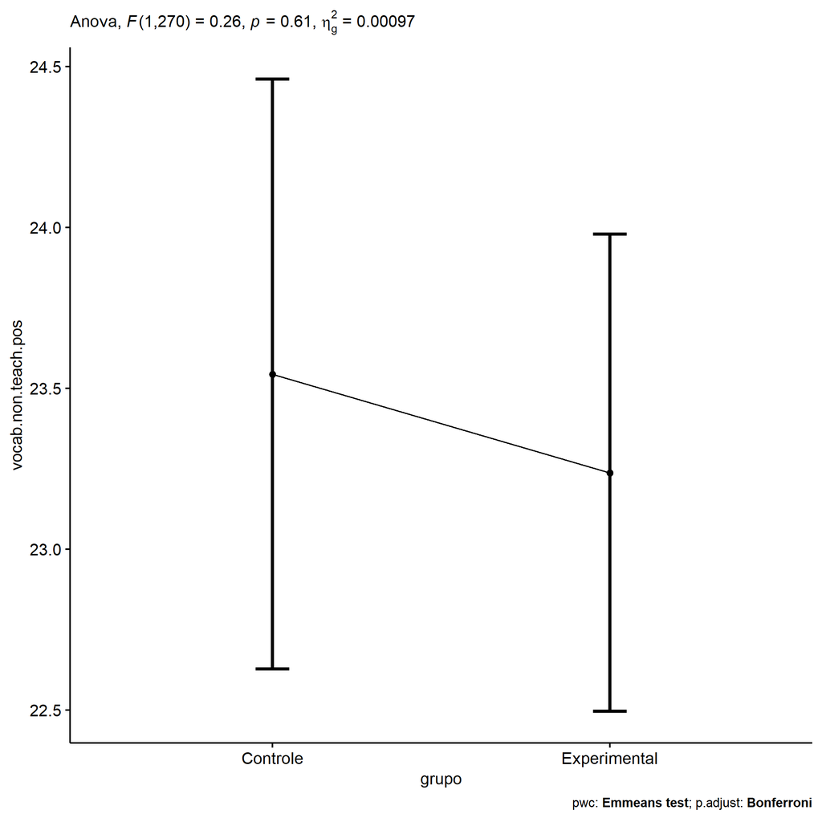

```r
if (!is.null(nrow(plots[["grupo"]]$data)))
  plots[["grupo"]] + ggplot2::scale_color_manual(values = color[["grupo"]])
```

```r
plots <- oneWayAncovaBoxPlots(
  wdat, "vocab.non.teach.pos", "grupo", aov, pwc, covar = "vocab.non.teach.pre",
  theme = "classic", color = color[["grupo"]],
  subtitle = which(aov$Effect == "grupo"))
```

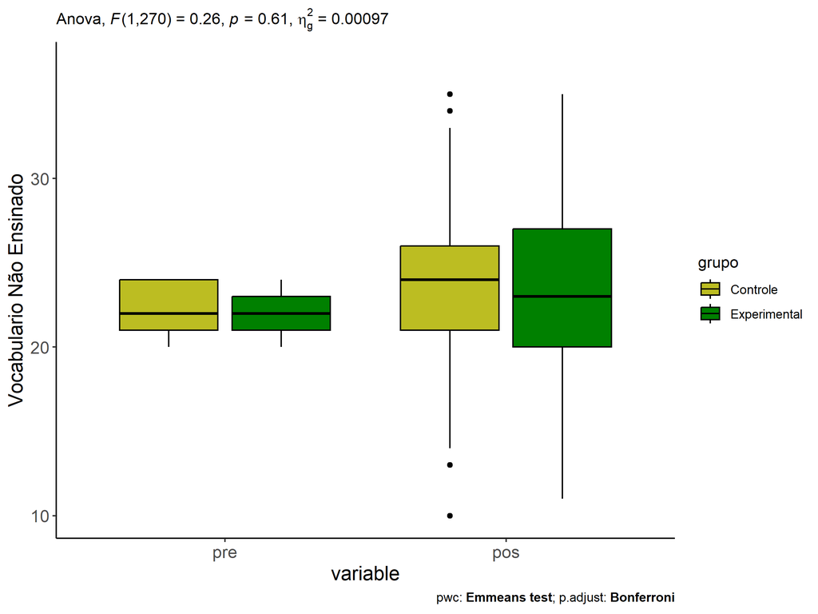

```r
if (length(unique(wdat[["grupo"]])) > 1)
  plots[["grupo"]] + ggplot2::ylab("Vocabulario Não Ensinado") + ggplot2::scale_x_discrete(labels=c('pre', 'pos'))
```

```r
if (length(unique(wdat.long[["grupo"]])) > 1)
  plots <- oneWayAncovaBoxPlots(
    wdat.long, "vocab.non.teach", "grupo", aov, pwc.long, pre.post = "time",
    theme = "classic", color = color$prepost)
```

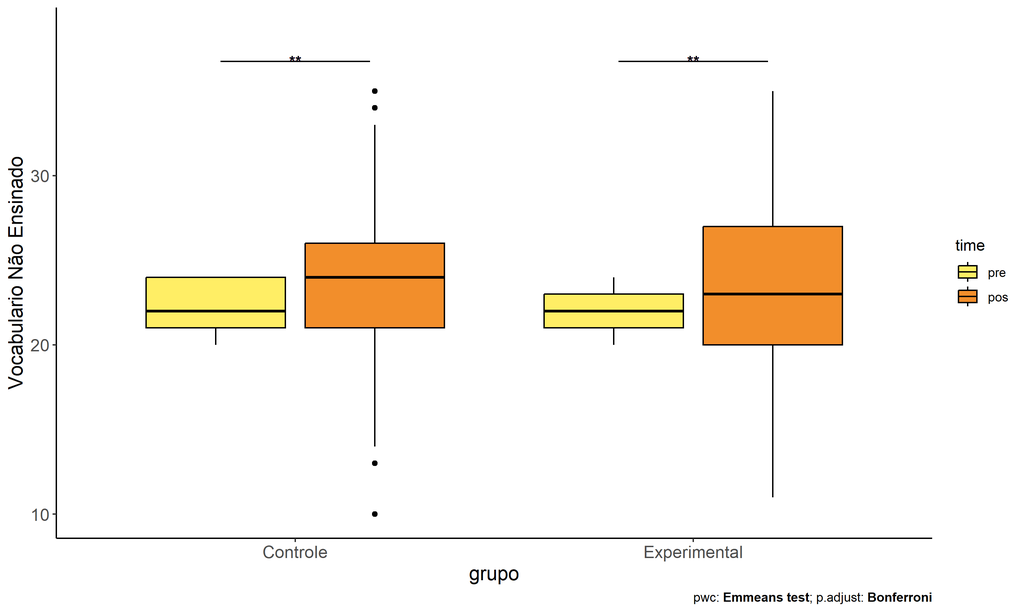

```r
if (length(unique(wdat.long[["grupo"]])) > 1)
  plots[["grupo"]] + ggplot2::ylab("Vocabulario Não Ensinado")
```

### Checking linearity assumption

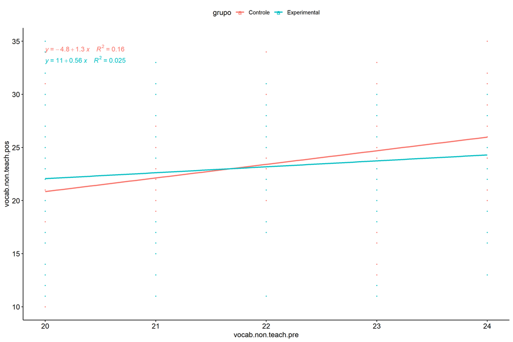

```r
ggscatter(wdat, x = "vocab.non.teach.pre", y = "vocab.non.teach.pos", size = 0.5,
          color = "grupo", add = "reg.line")+
  stat_regline_equation(
    aes(label =  paste(..eq.label.., ..rr.label.., sep = "~~~~"), color = grupo)
  )
```

### Checking normality and homogeneity

```r
res <- augment(lm(vocab.non.teach.pos ~ vocab.non.teach.pre + grupo, data = wdat))
```

```r
shapiro_test(res$.resid)
```

```
## # A tibble: 1 × 3
##   variable   statistic p.value
##   <chr>          <dbl>   <dbl>
## 1 res$.resid     0.990  0.0674
```

```r
levene_test(res, .resid ~ grupo)
```

```
## # A tibble: 1 × 4
##     df1   df2 statistic      p
##   <int> <int>     <dbl>  <dbl>
## 1     1   271      2.74 0.0989
```

# ANCOVA and Pairwise for two factors **grupo:Sexo**

## Without remove non-normal data

```r
pdat = remove_group_data(dat[!is.na(dat[["grupo"]]) & !is.na(dat[["Sexo"]]),], "vocab.non.teach.pos", c("grupo","Sexo"))

pdat.long <- rbind(pdat[,c("id","grupo","Sexo")], pdat[,c("id","grupo","Sexo")])
pdat.long[["time"]] <- c(rep("pre", nrow(pdat)), rep("pos", nrow(pdat)))
pdat.long[["time"]] <- factor(pdat.long[["time"]], c("pre","pos"))
pdat.long[["vocab.non.teach"]] <- c(pdat[["vocab.non.teach.pre"]], pdat[["vocab.non.teach.pos"]])

aov = anova_test(pdat, vocab.non.teach.pos ~ vocab.non.teach.pre + grupo*Sexo)
laov[["grupo:Sexo"]] <- get_anova_table(aov)
```

```r
pwcs <- list()
pwcs[["Sexo"]] <- emmeans_test(
  group_by(pdat, grupo), vocab.non.teach.pos ~ Sexo,
  covariate = vocab.non.teach.pre, p.adjust.method = "bonferroni")
pwcs[["grupo"]] <- emmeans_test(
  group_by(pdat, Sexo), vocab.non.teach.pos ~ grupo,
  covariate = vocab.non.teach.pre, p.adjust.method = "bonferroni")

pwc <- plyr::rbind.fill(pwcs[["grupo"]], pwcs[["Sexo"]])
pwc <- pwc[,c("grupo","Sexo", colnames(pwc)[!colnames(pwc) %in% c("grupo","Sexo")])]
```

```r
pwc.long <- emmeans_test(dplyr::group_by_at(pdat.long, c("grupo","Sexo")),
                         vocab.non.teach ~ time,
                         p.adjust.method = "bonferroni")
lpwc[["grupo:Sexo"]] <- plyr::rbind.fill(pwc, pwc.long)
```

```r
ds <- get.descriptives(pdat, "vocab.non.teach.pos", c("grupo","Sexo"), covar = "vocab.non.teach.pre")
ds <- merge(ds[ds$variable != "vocab.non.teach.pre",],
            ds[ds$variable == "vocab.non.teach.pre", !colnames(ds) %in% c("variable")],
            by = c("grupo","Sexo"), all.x = T, suffixes = c("", ".vocab.non.teach.pre"))
ds <- merge(get_emmeans(pwcs[["grupo"]]), ds, by = c("grupo","Sexo"), suffixes = c(".emms", ""))
ds <- ds[,c("grupo","Sexo","n","mean.vocab.non.teach.pre","se.vocab.non.teach.pre","mean","se","emmean","se.emms")]

colnames(ds) <- c("grupo","Sexo", "N", paste0(c("M","SE")," (pre)"),
                  paste0(c("M","SE"), " (unadj)"), paste0(c("M", "SE"), " (adj)"))

lemms[["grupo:Sexo"]] <- ds
```

## Computing ANCOVA and PairWise After removing non-normal data (OK)

```r
wdat = pdat

res = residuals(lm(vocab.non.teach.pos ~ vocab.non.teach.pre + grupo*Sexo, data = wdat))
non.normal = getNonNormal(res, wdat$id, plimit = 0.05)

wdat = wdat[!wdat$id %in% non.normal,]

wdat.long <- rbind(wdat[,c("id","grupo","Sexo")], wdat[,c("id","grupo","Sexo")])
wdat.long[["time"]] <- c(rep("pre", nrow(wdat)), rep("pos", nrow(wdat)))
wdat.long[["time"]] <- factor(wdat.long[["time"]], c("pre","pos"))
wdat.long[["vocab.non.teach"]] <- c(wdat[["vocab.non.teach.pre"]], wdat[["vocab.non.teach.pos"]])


ldat[["grupo:Sexo"]] = wdat

(non.normal)
```

```
## [1] "P1113" "P2251" "P1056"
```

```r
aov = anova_test(wdat, vocab.non.teach.pos ~ vocab.non.teach.pre + grupo*Sexo)
laov[["grupo:Sexo"]] <- merge(get_anova_table(aov), laov[["grupo:Sexo"]], by="Effect", suffixes = c("","'"))

(df = get_anova_table(aov))
```

```
## ANOVA Table (type II tests)
##
##                Effect DFn DFd      F        p p<.05   ges
## 1 vocab.non.teach.pre   1 269 17.247 4.41e-05     * 0.060
## 2               grupo   1 269  0.365 5.46e-01       0.001
## 3                Sexo   1 269  2.631 1.06e-01       0.010
## 4          grupo:Sexo   1 269  1.607 2.06e-01       0.006
```

| Effect | DFn | DFd | F | p | p<.05 | ges |
| --- | --- | --- | --- | --- | --- | --- |
| vocab.non.teach.pre | 1 | 269 | 17.247 | 0.000 | * | 0.060 |
| grupo | 1 | 269 | 0.365 | 0.546 |  | 0.001 |
| Sexo | 1 | 269 | 2.631 | 0.106 |  | 0.010 |
| grupo:Sexo | 1 | 269 | 1.607 | 0.206 |  | 0.006 |

```r
pwcs <- list()
pwcs[["Sexo"]] <- emmeans_test(
  group_by(wdat, grupo), vocab.non.teach.pos ~ Sexo,
  covariate = vocab.non.teach.pre, p.adjust.method = "bonferroni")
pwcs[["grupo"]] <- emmeans_test(
  group_by(wdat, Sexo), vocab.non.teach.pos ~ grupo,
  covariate = vocab.non.teach.pre, p.adjust.method = "bonferroni")

pwc <- plyr::rbind.fill(pwcs[["grupo"]], pwcs[["Sexo"]])
pwc <- pwc[,c("grupo","Sexo", colnames(pwc)[!colnames(pwc) %in% c("grupo","Sexo")])]
```

| grupo | Sexo | term | .y. | group1 | group2 | df | statistic | p | p.adj | p.adj.signif |
| --- | --- | --- | --- | --- | --- | --- | --- | --- | --- | --- |
|  | F | vocab.non.teach.pre*grupo | vocab.non.teach.pos | Controle | Experimental | 269 | 1.288 | 0.199 | 0.199 | ns |
|  | M | vocab.non.teach.pre*grupo | vocab.non.teach.pos | Controle | Experimental | 269 | -0.556 | 0.579 | 0.579 | ns |
| Controle |  | vocab.non.teach.pre*Sexo | vocab.non.teach.pos | F | M | 269 | 2.003 | 0.046 | 0.046 | * |
| Experimental |  | vocab.non.teach.pre*Sexo | vocab.non.teach.pos | F | M | 269 | 0.477 | 0.633 | 0.633 | ns |

```r
pwc.long <- emmeans_test(dplyr::group_by_at(wdat.long, c("grupo","Sexo")),
                         vocab.non.teach ~ time,
                         p.adjust.method = "bonferroni")
lpwc[["grupo:Sexo"]] <- merge(plyr::rbind.fill(pwc, pwc.long), lpwc[["grupo:Sexo"]], by=c("grupo","Sexo","term",".y.","group1","group2"), suffixes = c("","'"))
```

| grupo | Sexo | term | .y. | group1 | group2 | df | statistic | p | p.adj | p.adj.signif |
| --- | --- | --- | --- | --- | --- | --- | --- | --- | --- | --- |
| Controle | F | time | vocab.non.teach | pre | pos | 540 | -3.422 | 0.001 | 0.001 | *** |
| Controle | M | time | vocab.non.teach | pre | pos | 540 | -0.425 | 0.671 | 0.671 | ns |
| Experimental | F | time | vocab.non.teach | pre | pos | 540 | -2.262 | 0.024 | 0.024 | * |
| Experimental | M | time | vocab.non.teach | pre | pos | 540 | -1.460 | 0.145 | 0.145 | ns |

```r
ds <- get.descriptives(wdat, "vocab.non.teach.pos", c("grupo","Sexo"), covar = "vocab.non.teach.pre")
ds <- merge(ds[ds$variable != "vocab.non.teach.pre",],
            ds[ds$variable == "vocab.non.teach.pre", !colnames(ds) %in% c("variable")],
            by = c("grupo","Sexo"), all.x = T, suffixes = c("", ".vocab.non.teach.pre"))
ds <- merge(get_emmeans(pwcs[["grupo"]]), ds, by = c("grupo","Sexo"), suffixes = c(".emms", ""))
ds <- ds[,c("grupo","Sexo","n","mean.vocab.non.teach.pre","se.vocab.non.teach.pre","mean","se","emmean","se.emms")]

colnames(ds) <- c("grupo","Sexo", "N", paste0(c("M","SE")," (pre)"),
                  paste0(c("M","SE"), " (unadj)"), paste0(c("M", "SE"), " (adj)"))

lemms[["grupo:Sexo"]] <- merge(ds, lemms[["grupo:Sexo"]], by=c("grupo","Sexo"), suffixes = c("","'"))
```

| grupo | Sexo | N | M (pre) | SE (pre) | M (unadj) | SE (unadj) | M (adj) | SE (adj) |
| --- | --- | --- | --- | --- | --- | --- | --- | --- |
| Controle | F | 63 | 22.143 | 0.188 | 24.413 | 0.552 | 24.344 | 0.620 |
| Controle | M | 45 | 22.244 | 0.211 | 22.578 | 0.745 | 22.422 | 0.734 |
| Experimental | F | 90 | 21.956 | 0.147 | 23.211 | 0.556 | 23.302 | 0.519 |
| Experimental | M | 76 | 22.013 | 0.172 | 22.895 | 0.614 | 22.937 | 0.564 |

### Plots for ancova

```r
plots <- twoWayAncovaPlots(
  wdat, "vocab.non.teach.pos", c("grupo","Sexo"), aov, pwcs, addParam = c("mean_se"),
  font.label.size=10, step.increase=0.05, p.label="p.adj",
  subtitle = which(aov$Effect == "grupo:Sexo"))
```

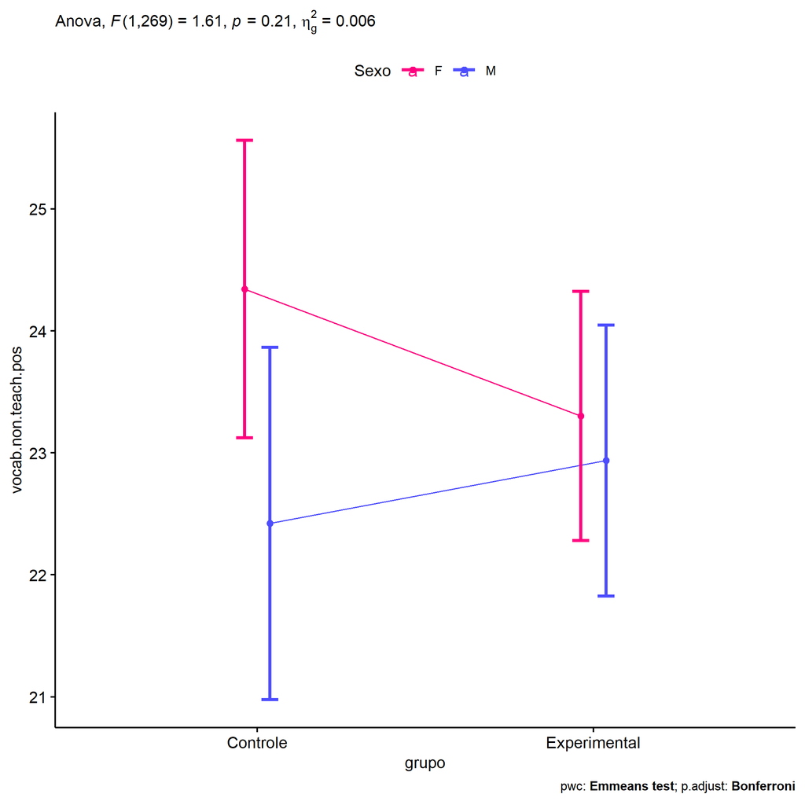

```r
if (!is.null(plots[["grupo"]]))
  plots[["grupo"]] + ggplot2::scale_color_manual(values = color[["Sexo"]])
```

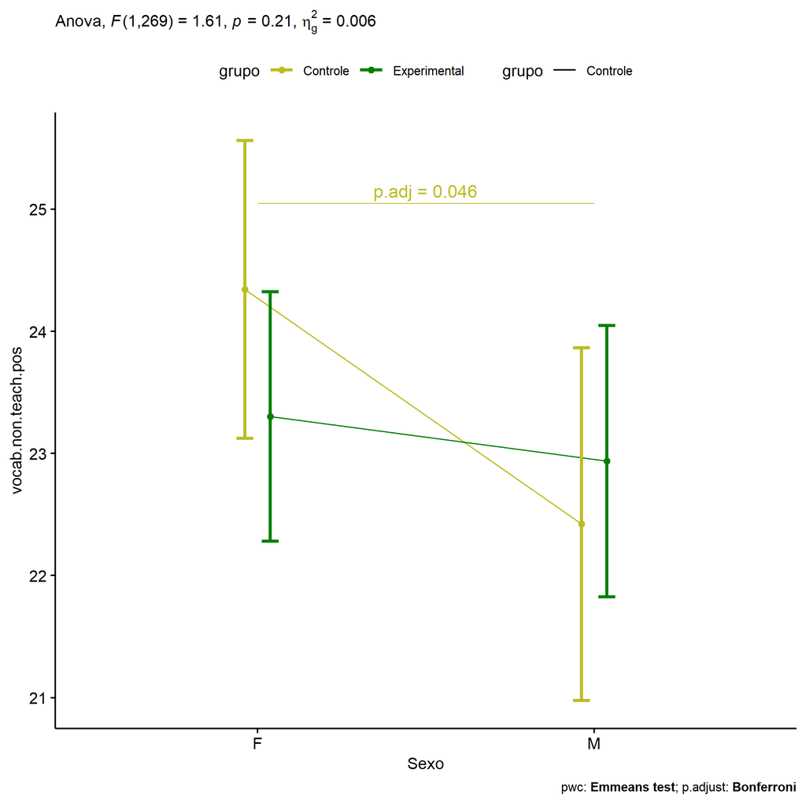

```r
if (!is.null(plots[["Sexo"]]))
  plots[["Sexo"]] + ggplot2::scale_color_manual(values = color[["grupo"]])
```

```r
plots <- twoWayAncovaBoxPlots(
  wdat, "vocab.non.teach.pos", c("grupo","Sexo"), aov, pwcs, covar = "vocab.non.teach.pre",
  theme = "classic", color = color[["grupo:Sexo"]],
  subtitle = which(aov$Effect == "grupo:Sexo"))
```

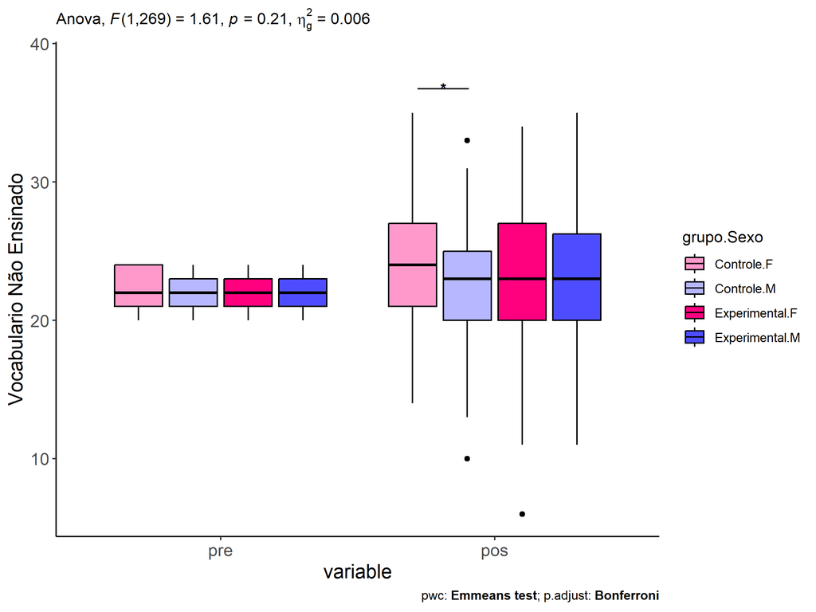

```r
plots[["grupo:Sexo"]] + ggplot2::ylab("Vocabulario Não Ensinado") + ggplot2::scale_x_discrete(labels=c('pre', 'pos'))
```

```r
plots <- twoWayAncovaBoxPlots(
  wdat.long, "vocab.non.teach", c("grupo","Sexo"), aov, pwc.long, pre.post = "time",
  theme = "classic", color = color$prepost)
```

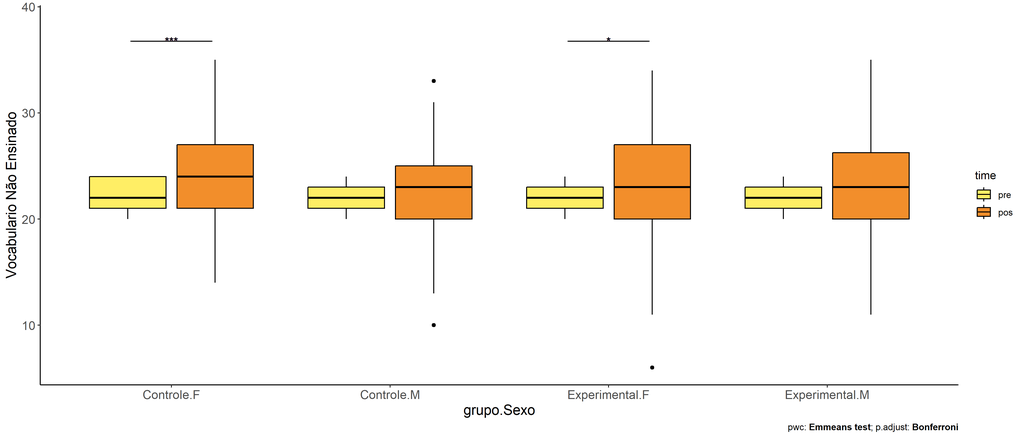

```r
plots[["grupo:Sexo"]] + ggplot2::ylab("Vocabulario Não Ensinado")
```

### Checking linearity assumption

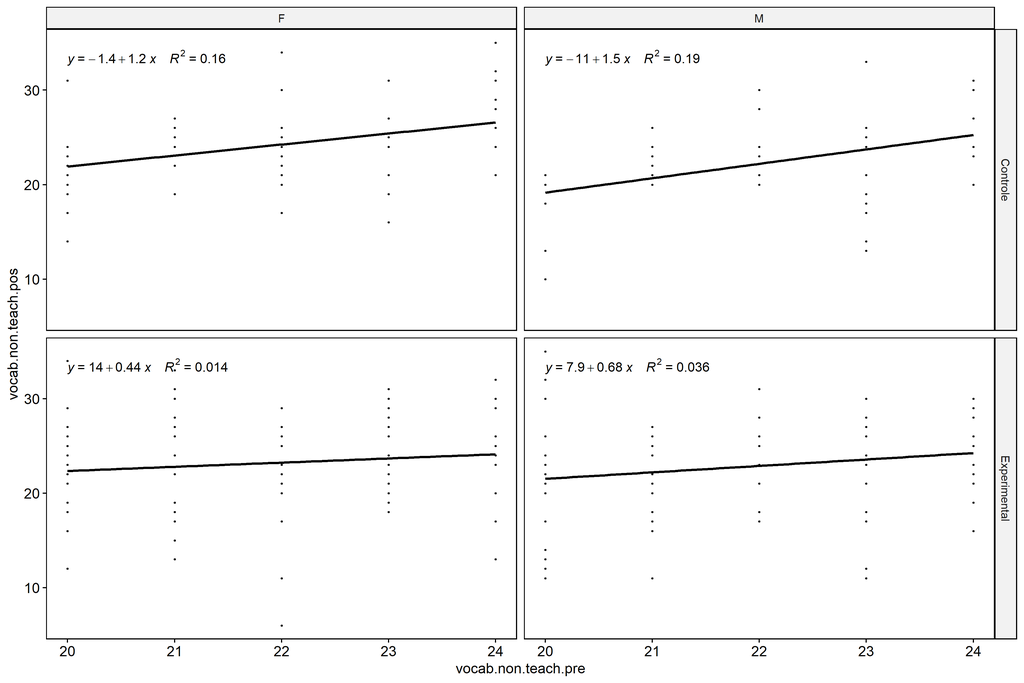

```r
ggscatter(wdat, x = "vocab.non.teach.pre", y = "vocab.non.teach.pos", size = 0.5,
          facet.by = c("grupo","Sexo"), add = "reg.line")+
  stat_regline_equation(
    aes(label =  paste(..eq.label.., ..rr.label.., sep = "~~~~"))
  )
```

### Checking normality and homogeneity

```r
res <- augment(lm(vocab.non.teach.pos ~ vocab.non.teach.pre + grupo*Sexo, data = wdat))
```

```r
shapiro_test(res$.resid)
```

```
## # A tibble: 1 × 3
##   variable   statistic p.value
##   <chr>          <dbl>   <dbl>
## 1 res$.resid     0.990  0.0664
```

```r
levene_test(res, .resid ~ grupo*Sexo)
```

```
## # A tibble: 1 × 4
##     df1   df2 statistic     p
##   <int> <int>     <dbl> <dbl>
## 1     3   270      1.44 0.233
```

# ANCOVA and Pairwise for two factors **grupo:Zona**

## Without remove non-normal data

```r
pdat = remove_group_data(dat[!is.na(dat[["grupo"]]) & !is.na(dat[["Zona"]]),], "vocab.non.teach.pos", c("grupo","Zona"))

pdat.long <- rbind(pdat[,c("id","grupo","Zona")], pdat[,c("id","grupo","Zona")])
pdat.long[["time"]] <- c(rep("pre", nrow(pdat)), rep("pos", nrow(pdat)))
pdat.long[["time"]] <- factor(pdat.long[["time"]], c("pre","pos"))
pdat.long[["vocab.non.teach"]] <- c(pdat[["vocab.non.teach.pre"]], pdat[["vocab.non.teach.pos"]])

aov = anova_test(pdat, vocab.non.teach.pos ~ vocab.non.teach.pre + grupo*Zona)
laov[["grupo:Zona"]] <- get_anova_table(aov)
```

```r
pwcs <- list()
pwcs[["Zona"]] <- emmeans_test(
  group_by(pdat, grupo), vocab.non.teach.pos ~ Zona,
  covariate = vocab.non.teach.pre, p.adjust.method = "bonferroni")
pwcs[["grupo"]] <- emmeans_test(
  group_by(pdat, Zona), vocab.non.teach.pos ~ grupo,
  covariate = vocab.non.teach.pre, p.adjust.method = "bonferroni")

pwc <- plyr::rbind.fill(pwcs[["grupo"]], pwcs[["Zona"]])
pwc <- pwc[,c("grupo","Zona", colnames(pwc)[!colnames(pwc) %in% c("grupo","Zona")])]
```

```r
pwc.long <- emmeans_test(dplyr::group_by_at(pdat.long, c("grupo","Zona")),
                         vocab.non.teach ~ time,
                         p.adjust.method = "bonferroni")
lpwc[["grupo:Zona"]] <- plyr::rbind.fill(pwc, pwc.long)
```

```r
ds <- get.descriptives(pdat, "vocab.non.teach.pos", c("grupo","Zona"), covar = "vocab.non.teach.pre")
ds <- merge(ds[ds$variable != "vocab.non.teach.pre",],
            ds[ds$variable == "vocab.non.teach.pre", !colnames(ds) %in% c("variable")],
            by = c("grupo","Zona"), all.x = T, suffixes = c("", ".vocab.non.teach.pre"))
ds <- merge(get_emmeans(pwcs[["grupo"]]), ds, by = c("grupo","Zona"), suffixes = c(".emms", ""))
ds <- ds[,c("grupo","Zona","n","mean.vocab.non.teach.pre","se.vocab.non.teach.pre","mean","se","emmean","se.emms")]

colnames(ds) <- c("grupo","Zona", "N", paste0(c("M","SE")," (pre)"),
                  paste0(c("M","SE"), " (unadj)"), paste0(c("M", "SE"), " (adj)"))

lemms[["grupo:Zona"]] <- ds
```

## Computing ANCOVA and PairWise After removing non-normal data (OK)

```r
wdat = pdat

res = residuals(lm(vocab.non.teach.pos ~ vocab.non.teach.pre + grupo*Zona, data = wdat))
non.normal = getNonNormal(res, wdat$id, plimit = 0.05)

wdat = wdat[!wdat$id %in% non.normal,]

wdat.long <- rbind(wdat[,c("id","grupo","Zona")], wdat[,c("id","grupo","Zona")])
wdat.long[["time"]] <- c(rep("pre", nrow(wdat)), rep("pos", nrow(wdat)))
wdat.long[["time"]] <- factor(wdat.long[["time"]], c("pre","pos"))
wdat.long[["vocab.non.teach"]] <- c(wdat[["vocab.non.teach.pre"]], wdat[["vocab.non.teach.pos"]])


ldat[["grupo:Zona"]] = wdat

(non.normal)
```

```
## [1] "P1056"
```

```r
aov = anova_test(wdat, vocab.non.teach.pos ~ vocab.non.teach.pre + grupo*Zona)
laov[["grupo:Zona"]] <- merge(get_anova_table(aov), laov[["grupo:Zona"]], by="Effect", suffixes = c("","'"))

(df = get_anova_table(aov))
```

```
## ANOVA Table (type II tests)
##
##                Effect DFn DFd      F        p p<.05      ges
## 1 vocab.non.teach.pre   1 196 13.426 0.000319     * 0.064000
## 2               grupo   1 196  0.667 0.415000       0.003000
## 3                Zona   1 196  0.449 0.503000       0.002000
## 4          grupo:Zona   1 196  0.026 0.872000       0.000133
```

| Effect | DFn | DFd | F | p | p<.05 | ges |
| --- | --- | --- | --- | --- | --- | --- |
| vocab.non.teach.pre | 1 | 196 | 13.426 | 0.000 | * | 0.064 |
| grupo | 1 | 196 | 0.667 | 0.415 |  | 0.003 |
| Zona | 1 | 196 | 0.449 | 0.503 |  | 0.002 |
| grupo:Zona | 1 | 196 | 0.026 | 0.872 |  | 0.000 |

```r
pwcs <- list()
pwcs[["Zona"]] <- emmeans_test(
  group_by(wdat, grupo), vocab.non.teach.pos ~ Zona,
  covariate = vocab.non.teach.pre, p.adjust.method = "bonferroni")
pwcs[["grupo"]] <- emmeans_test(
  group_by(wdat, Zona), vocab.non.teach.pos ~ grupo,
  covariate = vocab.non.teach.pre, p.adjust.method = "bonferroni")

pwc <- plyr::rbind.fill(pwcs[["grupo"]], pwcs[["Zona"]])
pwc <- pwc[,c("grupo","Zona", colnames(pwc)[!colnames(pwc) %in% c("grupo","Zona")])]
```

| grupo | Zona | term | .y. | group1 | group2 | df | statistic | p | p.adj | p.adj.signif |
| --- | --- | --- | --- | --- | --- | --- | --- | --- | --- | --- |
|  | Rural | vocab.non.teach.pre*grupo | vocab.non.teach.pos | Controle | Experimental | 196 | 0.776 | 0.439 | 0.439 | ns |
|  | Urbana | vocab.non.teach.pre*grupo | vocab.non.teach.pos | Controle | Experimental | 196 | 0.295 | 0.768 | 0.768 | ns |
| Controle |  | vocab.non.teach.pre*Zona | vocab.non.teach.pos | Rural | Urbana | 196 | 0.520 | 0.603 | 0.603 | ns |
| Experimental |  | vocab.non.teach.pre*Zona | vocab.non.teach.pos | Rural | Urbana | 196 | 0.452 | 0.652 | 0.652 | ns |

```r
pwc.long <- emmeans_test(dplyr::group_by_at(wdat.long, c("grupo","Zona")),
                         vocab.non.teach ~ time,
                         p.adjust.method = "bonferroni")
lpwc[["grupo:Zona"]] <- merge(plyr::rbind.fill(pwc, pwc.long), lpwc[["grupo:Zona"]], by=c("grupo","Zona","term",".y.","group1","group2"), suffixes = c("","'"))
```

| grupo | Zona | term | .y. | group1 | group2 | df | statistic | p | p.adj | p.adj.signif |
| --- | --- | --- | --- | --- | --- | --- | --- | --- | --- | --- |
| Controle | Rural | time | vocab.non.teach | pre | pos | 394 | -2.950 | 0.003 | 0.003 | ** |
| Controle | Urbana | time | vocab.non.teach | pre | pos | 394 | -1.175 | 0.241 | 0.241 | ns |
| Experimental | Rural | time | vocab.non.teach | pre | pos | 394 | -2.312 | 0.021 | 0.021 | * |
| Experimental | Urbana | time | vocab.non.teach | pre | pos | 394 | -1.217 | 0.224 | 0.224 | ns |

```r
ds <- get.descriptives(wdat, "vocab.non.teach.pos", c("grupo","Zona"), covar = "vocab.non.teach.pre")
ds <- merge(ds[ds$variable != "vocab.non.teach.pre",],
            ds[ds$variable == "vocab.non.teach.pre", !colnames(ds) %in% c("variable")],
            by = c("grupo","Zona"), all.x = T, suffixes = c("", ".vocab.non.teach.pre"))
ds <- merge(get_emmeans(pwcs[["grupo"]]), ds, by = c("grupo","Zona"), suffixes = c(".emms", ""))
ds <- ds[,c("grupo","Zona","n","mean.vocab.non.teach.pre","se.vocab.non.teach.pre","mean","se","emmean","se.emms")]

colnames(ds) <- c("grupo","Zona", "N", paste0(c("M","SE")," (pre)"),
                  paste0(c("M","SE"), " (unadj)"), paste0(c("M", "SE"), " (adj)"))

lemms[["grupo:Zona"]] <- merge(ds, lemms[["grupo:Zona"]], by=c("grupo","Zona"), suffixes = c("","'"))
```

| grupo | Zona | N | M (pre) | SE (pre) | M (unadj) | SE (unadj) | M (adj) | SE (adj) |
| --- | --- | --- | --- | --- | --- | --- | --- | --- |
| Controle | Rural | 61 | 22.426 | 0.176 | 24.344 | 0.592 | 24.093 | 0.609 |
| Controle | Urbana | 19 | 21.684 | 0.325 | 23.053 | 0.839 | 23.441 | 1.089 |
| Experimental | Rural | 77 | 22.052 | 0.171 | 23.390 | 0.587 | 23.461 | 0.539 |
| Experimental | Urbana | 44 | 22.068 | 0.209 | 23.000 | 0.776 | 23.057 | 0.712 |

### Plots for ancova

```r
plots <- twoWayAncovaPlots(
  wdat, "vocab.non.teach.pos", c("grupo","Zona"), aov, pwcs, addParam = c("mean_se"),
  font.label.size=10, step.increase=0.05, p.label="p.adj",
  subtitle = which(aov$Effect == "grupo:Zona"))
```

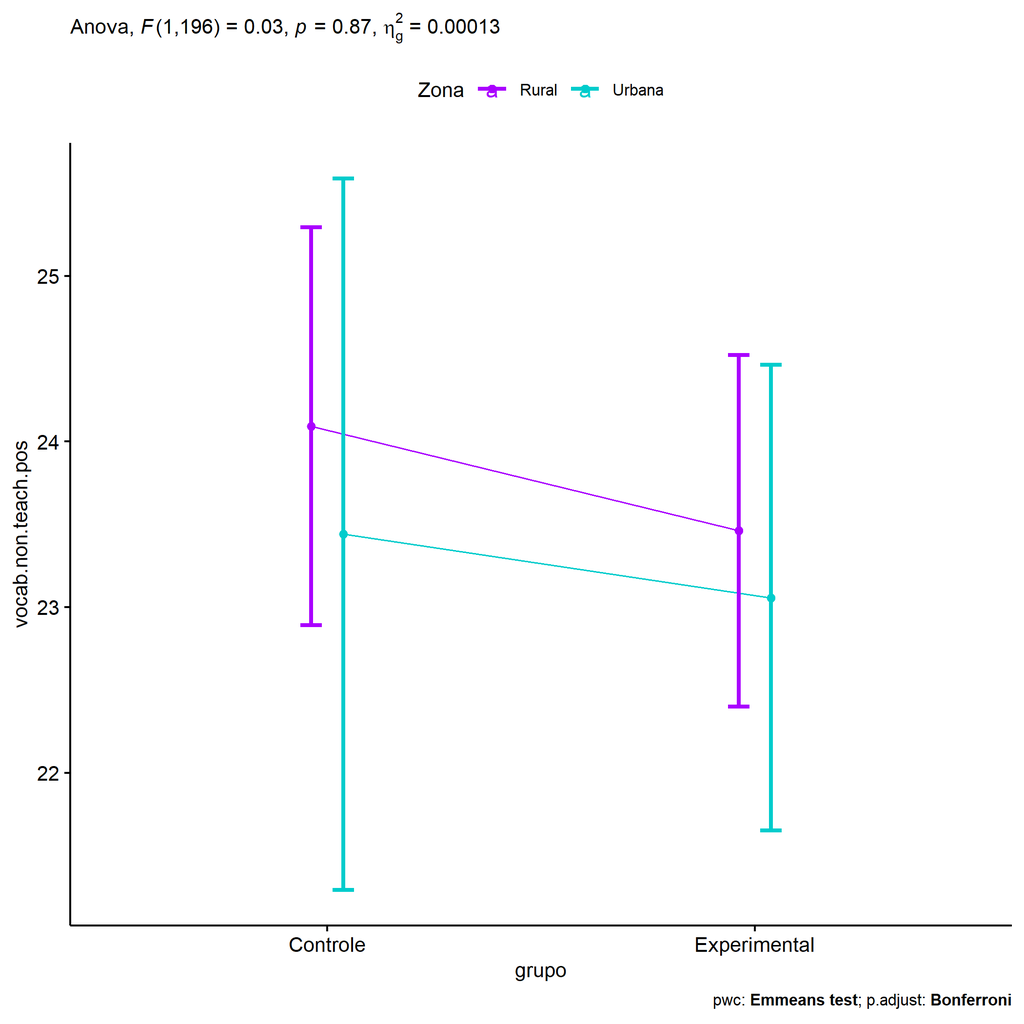

```r
if (!is.null(plots[["grupo"]]))
  plots[["grupo"]] + ggplot2::scale_color_manual(values = color[["Zona"]])
```

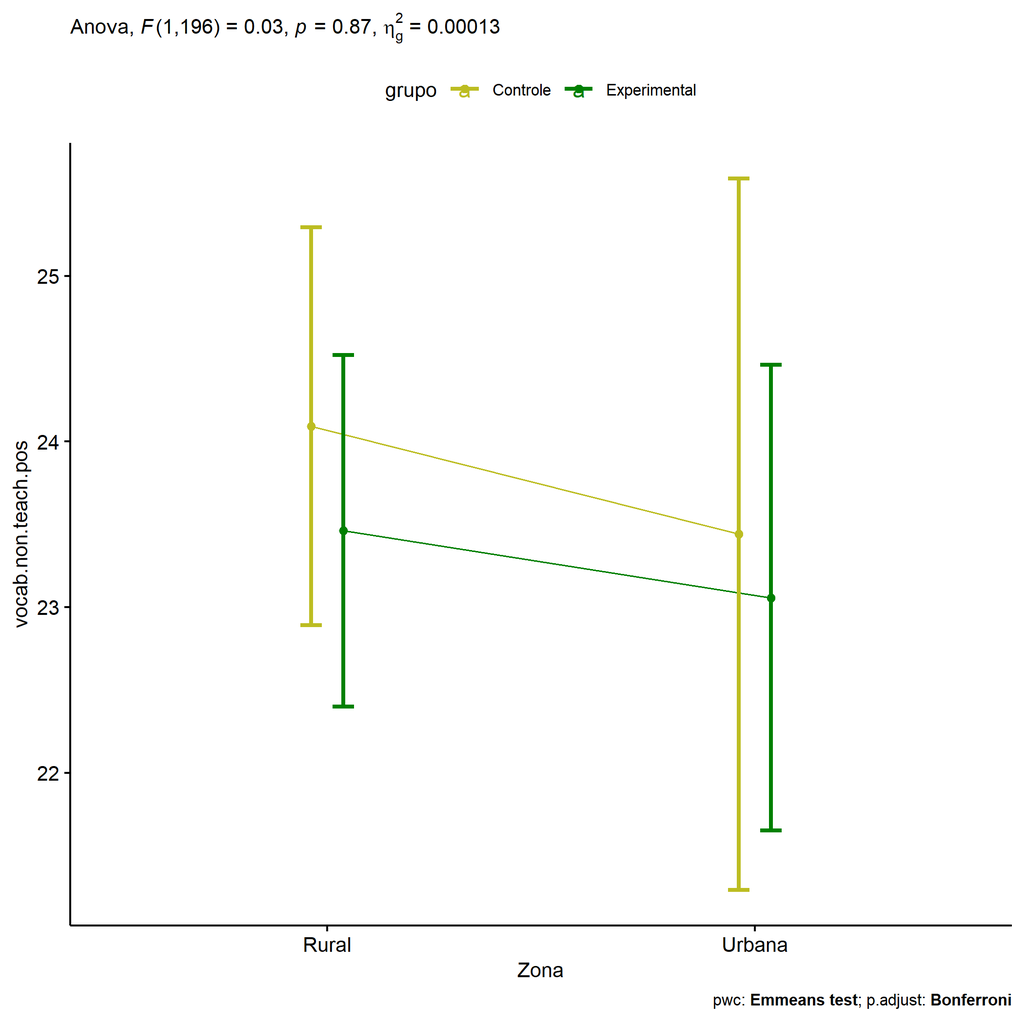

```r
if (!is.null(plots[["Zona"]]))
  plots[["Zona"]] + ggplot2::scale_color_manual(values = color[["grupo"]])
```

```r
plots <- twoWayAncovaBoxPlots(
  wdat, "vocab.non.teach.pos", c("grupo","Zona"), aov, pwcs, covar = "vocab.non.teach.pre",
  theme = "classic", color = color[["grupo:Zona"]],
  subtitle = which(aov$Effect == "grupo:Zona"))
```

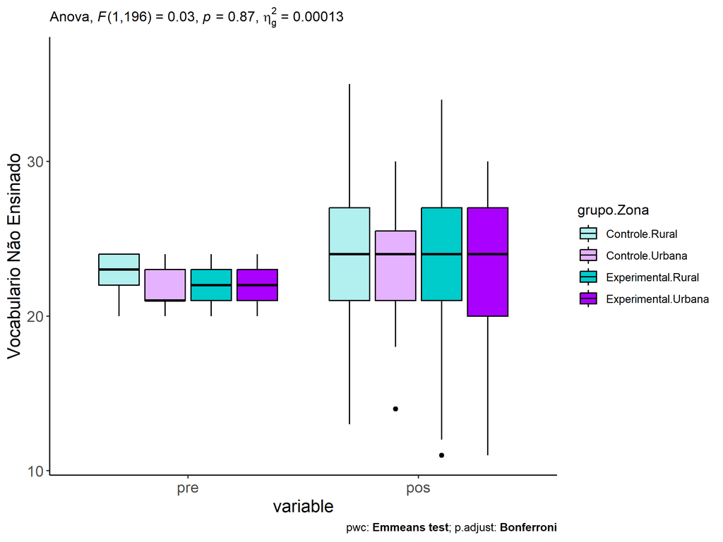

```r
plots[["grupo:Zona"]] + ggplot2::ylab("Vocabulario Não Ensinado") + ggplot2::scale_x_discrete(labels=c('pre', 'pos'))
```

```r
plots <- twoWayAncovaBoxPlots(
  wdat.long, "vocab.non.teach", c("grupo","Zona"), aov, pwc.long, pre.post = "time",
  theme = "classic", color = color$prepost)
```

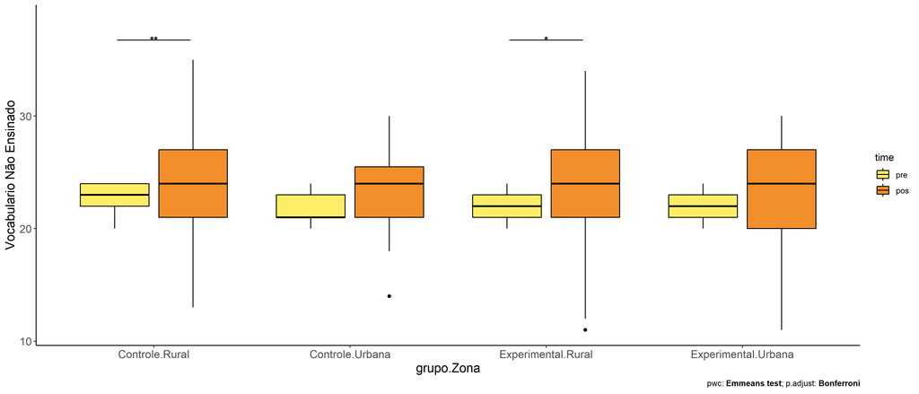

```r
plots[["grupo:Zona"]] + ggplot2::ylab("Vocabulario Não Ensinado")
```

### Checking linearity assumption

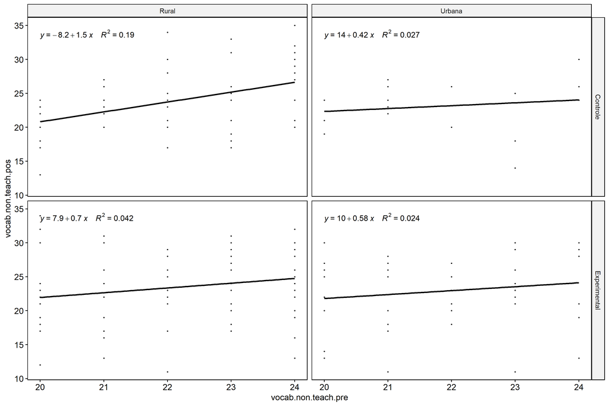

```r
ggscatter(wdat, x = "vocab.non.teach.pre", y = "vocab.non.teach.pos", size = 0.5,
          facet.by = c("grupo","Zona"), add = "reg.line")+
  stat_regline_equation(
    aes(label =  paste(..eq.label.., ..rr.label.., sep = "~~~~"))
  )
```

### Checking normality and homogeneity

```r
res <- augment(lm(vocab.non.teach.pos ~ vocab.non.teach.pre + grupo*Zona, data = wdat))
```

```r
shapiro_test(res$.resid)
```

```
## # A tibble: 1 × 3
##   variable   statistic p.value
##   <chr>          <dbl>   <dbl>
## 1 res$.resid     0.989   0.112
```

```r
levene_test(res, .resid ~ grupo*Zona)
```

```
## # A tibble: 1 × 4
##     df1   df2 statistic     p
##   <int> <int>     <dbl> <dbl>
## 1     3   197      1.54 0.205
```

# ANCOVA and Pairwise for two factors **grupo:Cor.Raca**

## Without remove non-normal data

```r
pdat = remove_group_data(dat[!is.na(dat[["grupo"]]) & !is.na(dat[["Cor.Raca"]]),], "vocab.non.teach.pos", c("grupo","Cor.Raca"))
pdat.long <- rbind(pdat[,c("id","grupo","Cor.Raca")], pdat[,c("id","grupo","Cor.Raca")])
pdat.long[["time"]] <- c(rep("pre", nrow(pdat)), rep("pos", nrow(pdat)))
pdat.long[["time"]] <- factor(pdat.long[["time"]], c("pre","pos"))
pdat.long[["vocab.non.teach"]] <- c(pdat[["vocab.non.teach.pre"]], pdat[["vocab.non.teach.pos"]])

aov = anova_test(pdat, vocab.non.teach.pos ~ vocab.non.teach.pre + grupo*Cor.Raca)
laov[["grupo:Cor.Raca"]] <- get_anova_table(aov)
```

```r
pwcs <- list()
pwcs[["Cor.Raca"]] <- emmeans_test(
  group_by(pdat, grupo), vocab.non.teach.pos ~ Cor.Raca,
  covariate = vocab.non.teach.pre, p.adjust.method = "bonferroni")
pwcs[["grupo"]] <- emmeans_test(
  group_by(pdat, Cor.Raca), vocab.non.teach.pos ~ grupo,
  covariate = vocab.non.teach.pre, p.adjust.method = "bonferroni")

pwc <- plyr::rbind.fill(pwcs[["grupo"]], pwcs[["Cor.Raca"]])
pwc <- pwc[,c("grupo","Cor.Raca", colnames(pwc)[!colnames(pwc) %in% c("grupo","Cor.Raca")])]
```

```r
pwc.long <- emmeans_test(dplyr::group_by_at(pdat.long, c("grupo","Cor.Raca")),
                         vocab.non.teach ~ time,
                         p.adjust.method = "bonferroni")
lpwc[["grupo:Cor.Raca"]] <- plyr::rbind.fill(pwc, pwc.long)
```

```r
ds <- get.descriptives(pdat, "vocab.non.teach.pos", c("grupo","Cor.Raca"), covar = "vocab.non.teach.pre")
ds <- merge(ds[ds$variable != "vocab.non.teach.pre",],
            ds[ds$variable == "vocab.non.teach.pre", !colnames(ds) %in% c("variable")],
            by = c("grupo","Cor.Raca"), all.x = T, suffixes = c("", ".vocab.non.teach.pre"))
ds <- merge(get_emmeans(pwcs[["grupo"]]), ds, by = c("grupo","Cor.Raca"), suffixes = c(".emms", ""))
ds <- ds[,c("grupo","Cor.Raca","n","mean.vocab.non.teach.pre","se.vocab.non.teach.pre","mean","se","emmean","se.emms")]

colnames(ds) <- c("grupo","Cor.Raca", "N", paste0(c("M","SE")," (pre)"),
                  paste0(c("M","SE"), " (unadj)"), paste0(c("M", "SE"), " (adj)"))

lemms[["grupo:Cor.Raca"]] <- ds
```

## Computing ANCOVA and PairWise After removing non-normal data (OK)

```r
wdat = pdat

res = residuals(lm(vocab.non.teach.pos ~ vocab.non.teach.pre + grupo*Cor.Raca, data = wdat))
non.normal = getNonNormal(res, wdat$id, plimit = 0.05)

wdat = wdat[!wdat$id %in% non.normal,]

wdat.long <- rbind(wdat[,c("id","grupo","Cor.Raca")], wdat[,c("id","grupo","Cor.Raca")])
wdat.long[["time"]] <- c(rep("pre", nrow(wdat)), rep("pos", nrow(wdat)))
wdat.long[["time"]] <- factor(wdat.long[["time"]], c("pre","pos"))
wdat.long[["vocab.non.teach"]] <- c(wdat[["vocab.non.teach.pre"]], wdat[["vocab.non.teach.pos"]])


ldat[["grupo:Cor.Raca"]] = wdat

(non.normal)
```

```
## [1] "P1113" "P1056"
```

```r
aov = anova_test(wdat, vocab.non.teach.pos ~ vocab.non.teach.pre + grupo*Cor.Raca)
laov[["grupo:Cor.Raca"]] <- merge(get_anova_table(aov), laov[["grupo:Cor.Raca"]], by="Effect", suffixes = c("","'"))

(df = get_anova_table(aov))
```

```
## ANOVA Table (type II tests)
##
##                Effect DFn DFd      F        p p<.05   ges
## 1 vocab.non.teach.pre   1 108 19.677 2.22e-05     * 0.154
## 2               grupo   1 108  0.296 5.88e-01       0.003
## 3            Cor.Raca   2 108  3.595 3.10e-02     * 0.062
## 4      grupo:Cor.Raca   2 108  0.435 6.49e-01       0.008
```

| Effect | DFn | DFd | F | p | p<.05 | ges |
| --- | --- | --- | --- | --- | --- | --- |
| vocab.non.teach.pre | 1 | 108 | 19.677 | 0.000 | * | 0.154 |
| grupo | 1 | 108 | 0.296 | 0.588 |  | 0.003 |
| Cor.Raca | 2 | 108 | 3.595 | 0.031 | * | 0.062 |
| grupo:Cor.Raca | 2 | 108 | 0.435 | 0.649 |  | 0.008 |

```r
pwcs <- list()
pwcs[["Cor.Raca"]] <- emmeans_test(
  group_by(wdat, grupo), vocab.non.teach.pos ~ Cor.Raca,
  covariate = vocab.non.teach.pre, p.adjust.method = "bonferroni")
pwcs[["grupo"]] <- emmeans_test(
  group_by(wdat, Cor.Raca), vocab.non.teach.pos ~ grupo,
  covariate = vocab.non.teach.pre, p.adjust.method = "bonferroni")

pwc <- plyr::rbind.fill(pwcs[["grupo"]], pwcs[["Cor.Raca"]])
pwc <- pwc[,c("grupo","Cor.Raca", colnames(pwc)[!colnames(pwc) %in% c("grupo","Cor.Raca")])]
```

| grupo | Cor.Raca | term | .y. | group1 | group2 | df | statistic | p | p.adj | p.adj.signif |
| --- | --- | --- | --- | --- | --- | --- | --- | --- | --- | --- |
|  | Branca | vocab.non.teach.pre*grupo | vocab.non.teach.pos | Controle | Experimental | 108 | 0.959 | 0.340 | 0.340 | ns |
|  | Indígena | vocab.non.teach.pre*grupo | vocab.non.teach.pos | Controle | Experimental | 108 | -0.455 | 0.650 | 0.650 | ns |
|  | Parda | vocab.non.teach.pre*grupo | vocab.non.teach.pos | Controle | Experimental | 108 | 0.211 | 0.833 | 0.833 | ns |
| Controle |  | vocab.non.teach.pre*Cor.Raca | vocab.non.teach.pos | Branca | Indígena | 108 | -1.090 | 0.278 | 0.835 | ns |
| Controle |  | vocab.non.teach.pre*Cor.Raca | vocab.non.teach.pos | Branca | Parda | 108 | -1.064 | 0.290 | 0.869 | ns |
| Controle |  | vocab.non.teach.pre*Cor.Raca | vocab.non.teach.pos | Indígena | Parda | 108 | 0.429 | 0.669 | 1.000 | ns |
| Experimental |  | vocab.non.teach.pre*Cor.Raca | vocab.non.teach.pos | Branca | Indígena | 108 | -2.185 | 0.031 | 0.093 | ns |
| Experimental |  | vocab.non.teach.pre*Cor.Raca | vocab.non.teach.pos | Branca | Parda | 108 | -2.081 | 0.040 | 0.119 | ns |
| Experimental |  | vocab.non.teach.pre*Cor.Raca | vocab.non.teach.pos | Indígena | Parda | 108 | 1.092 | 0.277 | 0.832 | ns |

```r
pwc.long <- emmeans_test(dplyr::group_by_at(wdat.long, c("grupo","Cor.Raca")),
                         vocab.non.teach ~ time,
                         p.adjust.method = "bonferroni")
lpwc[["grupo:Cor.Raca"]] <- merge(plyr::rbind.fill(pwc, pwc.long), lpwc[["grupo:Cor.Raca"]], by=c("grupo","Cor.Raca","term",".y.","group1","group2"), suffixes = c("","'"))
```

| grupo | Cor.Raca | term | .y. | group1 | group2 | df | statistic | p | p.adj | p.adj.signif |
| --- | --- | --- | --- | --- | --- | --- | --- | --- | --- | --- |
| Controle | Branca | time | vocab.non.teach | pre | pos | 218 | -0.363 | 0.717 | 0.717 | ns |
| Controle | Indígena | time | vocab.non.teach | pre | pos | 218 | -1.297 | 0.196 | 0.196 | ns |
| Controle | Parda | time | vocab.non.teach | pre | pos | 218 | -1.943 | 0.053 | 0.053 | ns |
| Experimental | Branca | time | vocab.non.teach | pre | pos | 218 | 0.725 | 0.469 | 0.469 | ns |
| Experimental | Indígena | time | vocab.non.teach | pre | pos | 218 | -1.671 | 0.096 | 0.096 | ns |
| Experimental | Parda | time | vocab.non.teach | pre | pos | 218 | -2.101 | 0.037 | 0.037 | * |

```r
ds <- get.descriptives(wdat, "vocab.non.teach.pos", c("grupo","Cor.Raca"), covar = "vocab.non.teach.pre")
ds <- merge(ds[ds$variable != "vocab.non.teach.pre",],
            ds[ds$variable == "vocab.non.teach.pre", !colnames(ds) %in% c("variable")],
            by = c("grupo","Cor.Raca"), all.x = T, suffixes = c("", ".vocab.non.teach.pre"))
ds <- merge(get_emmeans(pwcs[["grupo"]]), ds, by = c("grupo","Cor.Raca"), suffixes = c(".emms", ""))
ds <- ds[,c("grupo","Cor.Raca","n","mean.vocab.non.teach.pre","se.vocab.non.teach.pre","mean","se","emmean","se.emms")]

colnames(ds) <- c("grupo","Cor.Raca", "N", paste0(c("M","SE")," (pre)"),
                  paste0(c("M","SE"), " (unadj)"), paste0(c("M", "SE"), " (adj)"))

lemms[["grupo:Cor.Raca"]] <- merge(ds, lemms[["grupo:Cor.Raca"]], by=c("grupo","Cor.Raca"), suffixes = c("","'"))
```

| grupo | Cor.Raca | N | M (pre) | SE (pre) | M (unadj) | SE (unadj) | M (adj) | SE (adj) |
| --- | --- | --- | --- | --- | --- | --- | --- | --- |
| Controle | Branca | 17 | 22.118 | 0.382 | 22.588 | 1.085 | 22.513 | 1.150 |
| Controle | Indígena | 6 | 21.833 | 0.833 | 24.667 | 1.726 | 24.968 | 1.936 |
| Controle | Parda | 29 | 21.862 | 0.271 | 23.793 | 1.009 | 24.056 | 0.882 |
| Experimental | Branca | 17 | 22.588 | 0.333 | 21.647 | 1.524 | 20.949 | 1.160 |
| Experimental | Indígena | 5 | 21.400 | 0.748 | 25.400 | 2.315 | 26.275 | 2.129 |
| Experimental | Parda | 41 | 22.073 | 0.235 | 23.829 | 0.738 | 23.813 | 0.740 |

### Plots for ancova

```r
plots <- twoWayAncovaPlots(
  wdat, "vocab.non.teach.pos", c("grupo","Cor.Raca"), aov, pwcs, addParam = c("mean_se"),
  font.label.size=10, step.increase=0.05, p.label="p.adj",
  subtitle = which(aov$Effect == "grupo:Cor.Raca"))
```

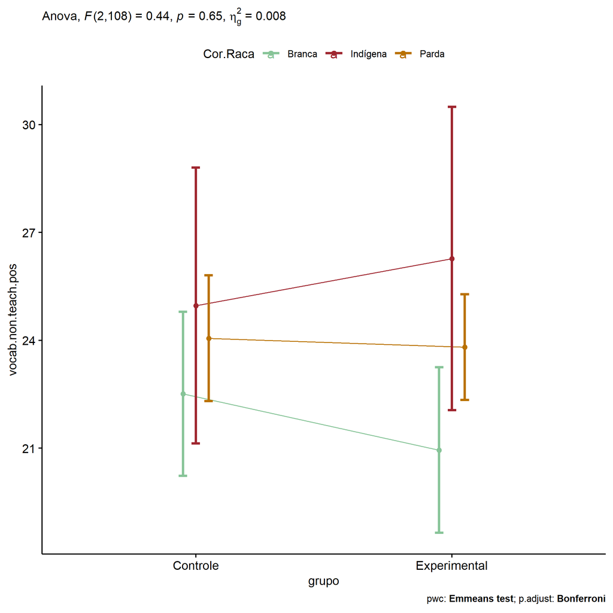

```r
if (!is.null(plots[["grupo"]]))
  plots[["grupo"]] + ggplot2::scale_color_manual(values = color[["Cor.Raca"]])
```

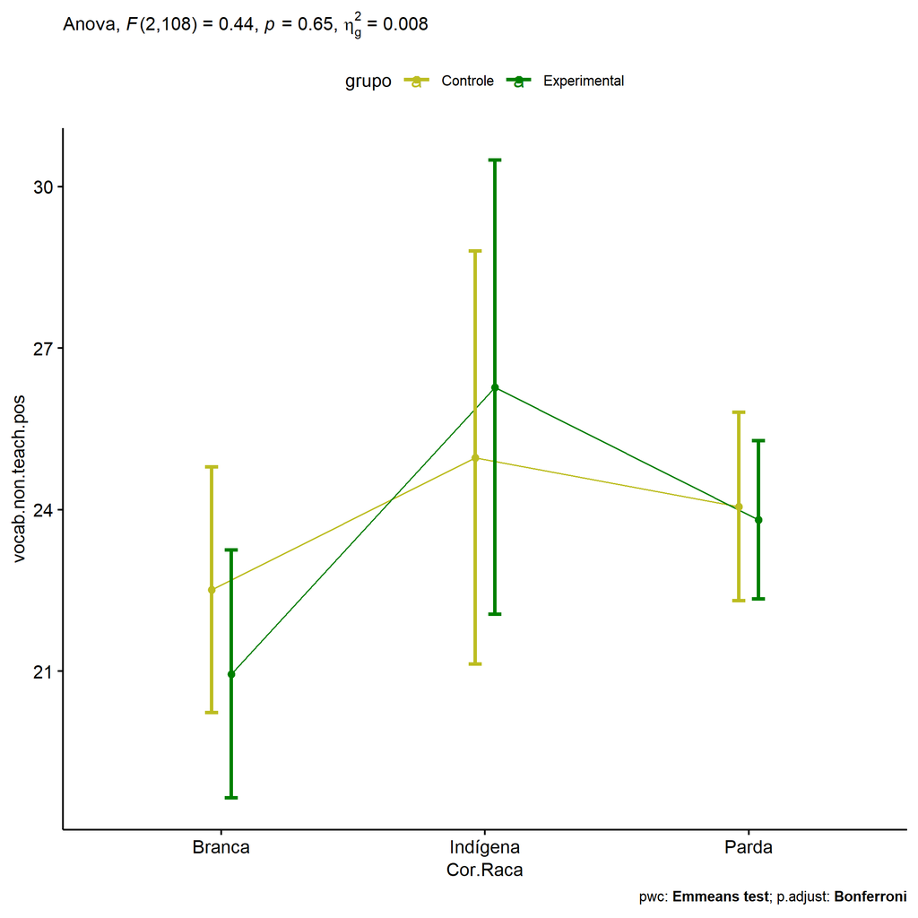

```r
if (!is.null(plots[["Cor.Raca"]]))
  plots[["Cor.Raca"]] + ggplot2::scale_color_manual(values = color[["grupo"]])
```

```r
plots <- twoWayAncovaBoxPlots(
  wdat, "vocab.non.teach.pos", c("grupo","Cor.Raca"), aov, pwcs, covar = "vocab.non.teach.pre",
  theme = "classic", color = color[["grupo:Cor.Raca"]],
  subtitle = which(aov$Effect == "grupo:Cor.Raca"))
```

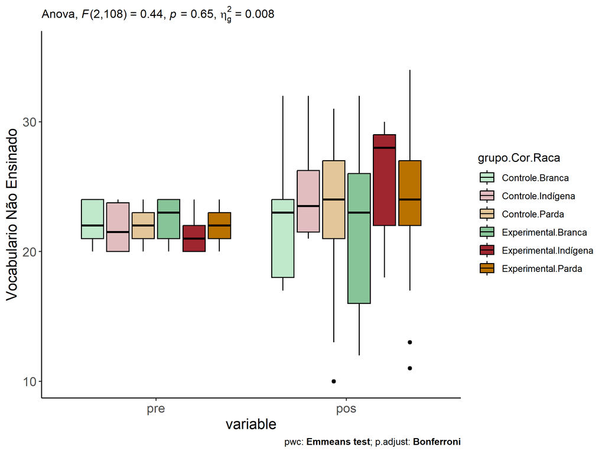

```r
plots[["grupo:Cor.Raca"]] + ggplot2::ylab("Vocabulario Não Ensinado") + ggplot2::scale_x_discrete(labels=c('pre', 'pos'))
```

```r
plots <- twoWayAncovaBoxPlots(
  wdat.long, "vocab.non.teach", c("grupo","Cor.Raca"), aov, pwc.long, pre.post = "time",
  theme = "classic", color = color$prepost)
```

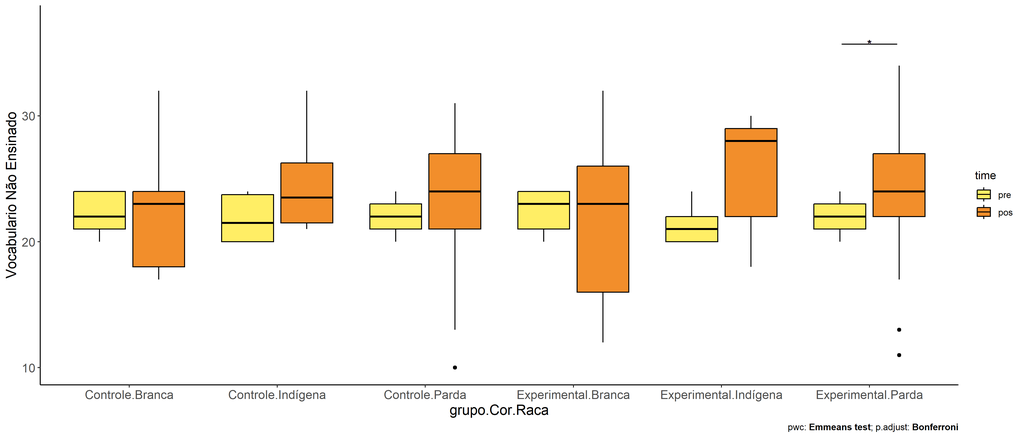

```r
plots[["grupo:Cor.Raca"]] + ggplot2::ylab("Vocabulario Não Ensinado")
```

### Checking linearity assumption

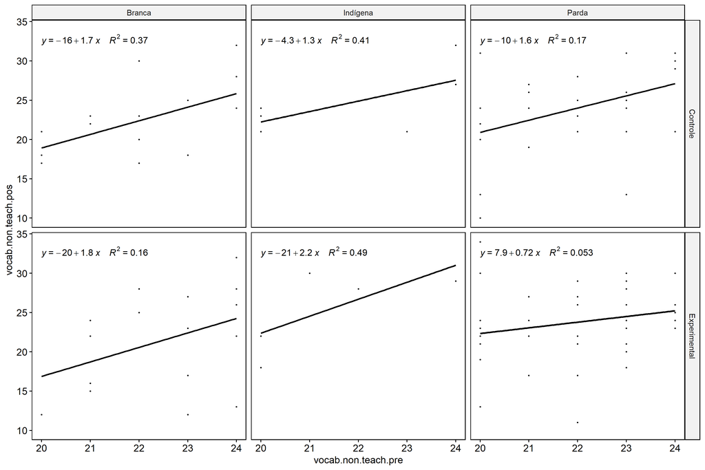

```r
ggscatter(wdat, x = "vocab.non.teach.pre", y = "vocab.non.teach.pos", size = 0.5,
          facet.by = c("grupo","Cor.Raca"), add = "reg.line")+
  stat_regline_equation(
    aes(label =  paste(..eq.label.., ..rr.label.., sep = "~~~~"))
  )
```

### Checking normality and homogeneity

```r
res <- augment(lm(vocab.non.teach.pos ~ vocab.non.teach.pre + grupo*Cor.Raca, data = wdat))
```

```r
shapiro_test(res$.resid)
```

```
## # A tibble: 1 × 3
##   variable   statistic p.value
##   <chr>          <dbl>   <dbl>
## 1 res$.resid     0.983   0.161
```

```r
levene_test(res, .resid ~ grupo*Cor.Raca)
```

```
## # A tibble: 1 × 4
##     df1   df2 statistic     p
##   <int> <int>     <dbl> <dbl>
## 1     5   109     0.918 0.472
```

# ANCOVA and Pairwise for two factors **grupo:Serie**

## Without remove non-normal data

```r
pdat = remove_group_data(dat[!is.na(dat[["grupo"]]) & !is.na(dat[["Serie"]]),], "vocab.non.teach.pos", c("grupo","Serie"))

pdat.long <- rbind(pdat[,c("id","grupo","Serie")], pdat[,c("id","grupo","Serie")])
pdat.long[["time"]] <- c(rep("pre", nrow(pdat)), rep("pos", nrow(pdat)))
pdat.long[["time"]] <- factor(pdat.long[["time"]], c("pre","pos"))
pdat.long[["vocab.non.teach"]] <- c(pdat[["vocab.non.teach.pre"]], pdat[["vocab.non.teach.pos"]])

aov = anova_test(pdat, vocab.non.teach.pos ~ vocab.non.teach.pre + grupo*Serie)
laov[["grupo:Serie"]] <- get_anova_table(aov)
```

```r
pwcs <- list()
pwcs[["Serie"]] <- emmeans_test(
  group_by(pdat, grupo), vocab.non.teach.pos ~ Serie,
  covariate = vocab.non.teach.pre, p.adjust.method = "bonferroni")
pwcs[["grupo"]] <- emmeans_test(
  group_by(pdat, Serie), vocab.non.teach.pos ~ grupo,
  covariate = vocab.non.teach.pre, p.adjust.method = "bonferroni")

pwc <- plyr::rbind.fill(pwcs[["grupo"]], pwcs[["Serie"]])
pwc <- pwc[,c("grupo","Serie", colnames(pwc)[!colnames(pwc) %in% c("grupo","Serie")])]
```

```r
pwc.long <- emmeans_test(dplyr::group_by_at(pdat.long, c("grupo","Serie")),
                         vocab.non.teach ~ time,
                         p.adjust.method = "bonferroni")
lpwc[["grupo:Serie"]] <- plyr::rbind.fill(pwc, pwc.long)
```

```r
ds <- get.descriptives(pdat, "vocab.non.teach.pos", c("grupo","Serie"), covar = "vocab.non.teach.pre")
ds <- merge(ds[ds$variable != "vocab.non.teach.pre",],
            ds[ds$variable == "vocab.non.teach.pre", !colnames(ds) %in% c("variable")],
            by = c("grupo","Serie"), all.x = T, suffixes = c("", ".vocab.non.teach.pre"))
ds <- merge(get_emmeans(pwcs[["grupo"]]), ds, by = c("grupo","Serie"), suffixes = c(".emms", ""))
ds <- ds[,c("grupo","Serie","n","mean.vocab.non.teach.pre","se.vocab.non.teach.pre","mean","se","emmean","se.emms")]

colnames(ds) <- c("grupo","Serie", "N", paste0(c("M","SE")," (pre)"),
                  paste0(c("M","SE"), " (unadj)"), paste0(c("M", "SE"), " (adj)"))

lemms[["grupo:Serie"]] <- ds
```

## Computing ANCOVA and PairWise After removing non-normal data (OK)

```r
wdat = pdat

res = residuals(lm(vocab.non.teach.pos ~ vocab.non.teach.pre + grupo*Serie, data = wdat))
non.normal = getNonNormal(res, wdat$id, plimit = 0.05)

wdat = wdat[!wdat$id %in% non.normal,]

wdat.long <- rbind(wdat[,c("id","grupo","Serie")], wdat[,c("id","grupo","Serie")])
wdat.long[["time"]] <- c(rep("pre", nrow(wdat)), rep("pos", nrow(wdat)))
wdat.long[["time"]] <- factor(wdat.long[["time"]], c("pre","pos"))
wdat.long[["vocab.non.teach"]] <- c(wdat[["vocab.non.teach.pre"]], wdat[["vocab.non.teach.pos"]])


ldat[["grupo:Serie"]] = wdat

(non.normal)
```

```
## [1] "P1113" "P2251" "P1056"
```

```r
aov = anova_test(wdat, vocab.non.teach.pos ~ vocab.non.teach.pre + grupo*Serie)
laov[["grupo:Serie"]] <- merge(get_anova_table(aov), laov[["grupo:Serie"]], by="Effect", suffixes = c("","'"))

(df = get_anova_table(aov))
```

```
## ANOVA Table (type II tests)
##
##                Effect DFn DFd      F       p p<.05   ges
## 1 vocab.non.teach.pre   1 265 14.800 0.00015     * 0.053
## 2               grupo   1 265  0.436 0.51000       0.002
## 3               Serie   3 265  2.815 0.04000     * 0.031
## 4         grupo:Serie   3 265  1.169 0.32200       0.013
```

| Effect | DFn | DFd | F | p | p<.05 | ges |
| --- | --- | --- | --- | --- | --- | --- |
| vocab.non.teach.pre | 1 | 265 | 14.800 | 0.000 | * | 0.053 |
| grupo | 1 | 265 | 0.436 | 0.510 |  | 0.002 |
| Serie | 3 | 265 | 2.815 | 0.040 | * | 0.031 |
| grupo:Serie | 3 | 265 | 1.169 | 0.322 |  | 0.013 |

```r
pwcs <- list()
pwcs[["Serie"]] <- emmeans_test(
  group_by(wdat, grupo), vocab.non.teach.pos ~ Serie,
  covariate = vocab.non.teach.pre, p.adjust.method = "bonferroni")
pwcs[["grupo"]] <- emmeans_test(
  group_by(wdat, Serie), vocab.non.teach.pos ~ grupo,
  covariate = vocab.non.teach.pre, p.adjust.method = "bonferroni")

pwc <- plyr::rbind.fill(pwcs[["grupo"]], pwcs[["Serie"]])
pwc <- pwc[,c("grupo","Serie", colnames(pwc)[!colnames(pwc) %in% c("grupo","Serie")])]
```

| grupo | Serie | term | .y. | group1 | group2 | df | statistic | p | p.adj | p.adj.signif |
| --- | --- | --- | --- | --- | --- | --- | --- | --- | --- | --- |
|  | 6 ano | vocab.non.teach.pre*grupo | vocab.non.teach.pos | Controle | Experimental | 265 | 0.806 | 0.421 | 0.421 | ns |
|  | 7 ano | vocab.non.teach.pre*grupo | vocab.non.teach.pos | Controle | Experimental | 265 | -0.199 | 0.842 | 0.842 | ns |
|  | 8 ano | vocab.non.teach.pre*grupo | vocab.non.teach.pos | Controle | Experimental | 265 | 1.602 | 0.110 | 0.110 | ns |
|  | 9 ano | vocab.non.teach.pre*grupo | vocab.non.teach.pos | Controle | Experimental | 265 | -0.825 | 0.410 | 0.410 | ns |
| Controle |  | vocab.non.teach.pre*Serie | vocab.non.teach.pos | 6 ano | 7 ano | 265 | 0.010 | 0.992 | 1.000 | ns |
| Controle |  | vocab.non.teach.pre*Serie | vocab.non.teach.pos | 6 ano | 8 ano | 265 | -1.042 | 0.298 | 1.000 | ns |
| Controle |  | vocab.non.teach.pre*Serie | vocab.non.teach.pos | 6 ano | 9 ano | 265 | -0.944 | 0.346 | 1.000 | ns |
| Controle |  | vocab.non.teach.pre*Serie | vocab.non.teach.pos | 7 ano | 8 ano | 265 | -1.066 | 0.287 | 1.000 | ns |
| Controle |  | vocab.non.teach.pre*Serie | vocab.non.teach.pos | 7 ano | 9 ano | 265 | -0.968 | 0.334 | 1.000 | ns |
| Controle |  | vocab.non.teach.pre*Serie | vocab.non.teach.pos | 8 ano | 9 ano | 265 | 0.115 | 0.909 | 1.000 | ns |
| Experimental |  | vocab.non.teach.pre*Serie | vocab.non.teach.pos | 6 ano | 7 ano | 265 | -1.138 | 0.256 | 1.000 | ns |
| Experimental |  | vocab.non.teach.pre*Serie | vocab.non.teach.pos | 6 ano | 8 ano | 265 | -0.284 | 0.776 | 1.000 | ns |
| Experimental |  | vocab.non.teach.pre*Serie | vocab.non.teach.pos | 6 ano | 9 ano | 265 | -2.896 | 0.004 | 0.025 | * |
| Experimental |  | vocab.non.teach.pre*Serie | vocab.non.teach.pos | 7 ano | 8 ano | 265 | 0.823 | 0.412 | 1.000 | ns |
| Experimental |  | vocab.non.teach.pre*Serie | vocab.non.teach.pos | 7 ano | 9 ano | 265 | -1.969 | 0.050 | 0.300 | ns |
| Experimental |  | vocab.non.teach.pre*Serie | vocab.non.teach.pos | 8 ano | 9 ano | 265 | -2.581 | 0.010 | 0.062 | ns |

```r
pwc.long <- emmeans_test(dplyr::group_by_at(wdat.long, c("grupo","Serie")),
                         vocab.non.teach ~ time,
                         p.adjust.method = "bonferroni")
lpwc[["grupo:Serie"]] <- merge(plyr::rbind.fill(pwc, pwc.long), lpwc[["grupo:Serie"]], by=c("grupo","Serie","term",".y.","group1","group2"), suffixes = c("","'"))
```

| grupo | Serie | term | .y. | group1 | group2 | df | statistic | p | p.adj | p.adj.signif |
| --- | --- | --- | --- | --- | --- | --- | --- | --- | --- | --- |
| Controle | 6 ano | time | vocab.non.teach | pre | pos | 532 | -0.926 | 0.355 | 0.355 | ns |
| Controle | 7 ano | time | vocab.non.teach | pre | pos | 532 | -0.896 | 0.371 | 0.371 | ns |
| Controle | 8 ano | time | vocab.non.teach | pre | pos | 532 | -2.120 | 0.034 | 0.034 | * |
| Controle | 9 ano | time | vocab.non.teach | pre | pos | 532 | -2.034 | 0.042 | 0.042 | * |
| Experimental | 6 ano | time | vocab.non.teach | pre | pos | 532 | 0.091 | 0.928 | 0.928 | ns |
| Experimental | 7 ano | time | vocab.non.teach | pre | pos | 532 | -1.543 | 0.123 | 0.123 | ns |
| Experimental | 8 ano | time | vocab.non.teach | pre | pos | 532 | -0.430 | 0.667 | 0.667 | ns |
| Experimental | 9 ano | time | vocab.non.teach | pre | pos | 532 | -3.600 | 0.000 | 0.000 | *** |

```r
ds <- get.descriptives(wdat, "vocab.non.teach.pos", c("grupo","Serie"), covar = "vocab.non.teach.pre")
ds <- merge(ds[ds$variable != "vocab.non.teach.pre",],
            ds[ds$variable == "vocab.non.teach.pre", !colnames(ds) %in% c("variable")],
            by = c("grupo","Serie"), all.x = T, suffixes = c("", ".vocab.non.teach.pre"))
ds <- merge(get_emmeans(pwcs[["grupo"]]), ds, by = c("grupo","Serie"), suffixes = c(".emms", ""))
ds <- ds[,c("grupo","Serie","n","mean.vocab.non.teach.pre","se.vocab.non.teach.pre","mean","se","emmean","se.emms")]

colnames(ds) <- c("grupo","Serie", "N", paste0(c("M","SE")," (pre)"),
                  paste0(c("M","SE"), " (unadj)"), paste0(c("M", "SE"), " (adj)"))

lemms[["grupo:Serie"]] <- merge(ds, lemms[["grupo:Serie"]], by=c("grupo","Serie"), suffixes = c("","'"))
```

| grupo | Serie | N | M (pre) | SE (pre) | M (unadj) | SE (unadj) | M (adj) | SE (adj) |
| --- | --- | --- | --- | --- | --- | --- | --- | --- |
| Controle | 6 ano | 29 | 22.069 | 0.297 | 22.966 | 0.895 | 22.960 | 0.907 |
| Controle | 7 ano | 31 | 22.290 | 0.279 | 23.129 | 0.836 | 22.947 | 0.878 |
| Controle | 8 ano | 23 | 22.130 | 0.290 | 24.435 | 0.895 | 24.380 | 1.018 |
| Controle | 9 ano | 25 | 22.240 | 0.254 | 24.360 | 1.020 | 24.218 | 0.977 |
| Experimental | 6 ano | 40 | 22.125 | 0.243 | 22.050 | 0.913 | 22.000 | 0.772 |
| Experimental | 7 ano | 52 | 22.019 | 0.177 | 23.135 | 0.677 | 23.169 | 0.677 |
| Experimental | 8 ano | 39 | 21.538 | 0.235 | 21.897 | 0.822 | 22.314 | 0.789 |
| Experimental | 9 ano | 35 | 22.257 | 0.251 | 25.429 | 0.831 | 25.273 | 0.826 |

### Plots for ancova

```r
plots <- twoWayAncovaPlots(
  wdat, "vocab.non.teach.pos", c("grupo","Serie"), aov, pwcs, addParam = c("mean_se"),
  font.label.size=10, step.increase=0.05, p.label="p.adj",
  subtitle = which(aov$Effect == "grupo:Serie"))
```

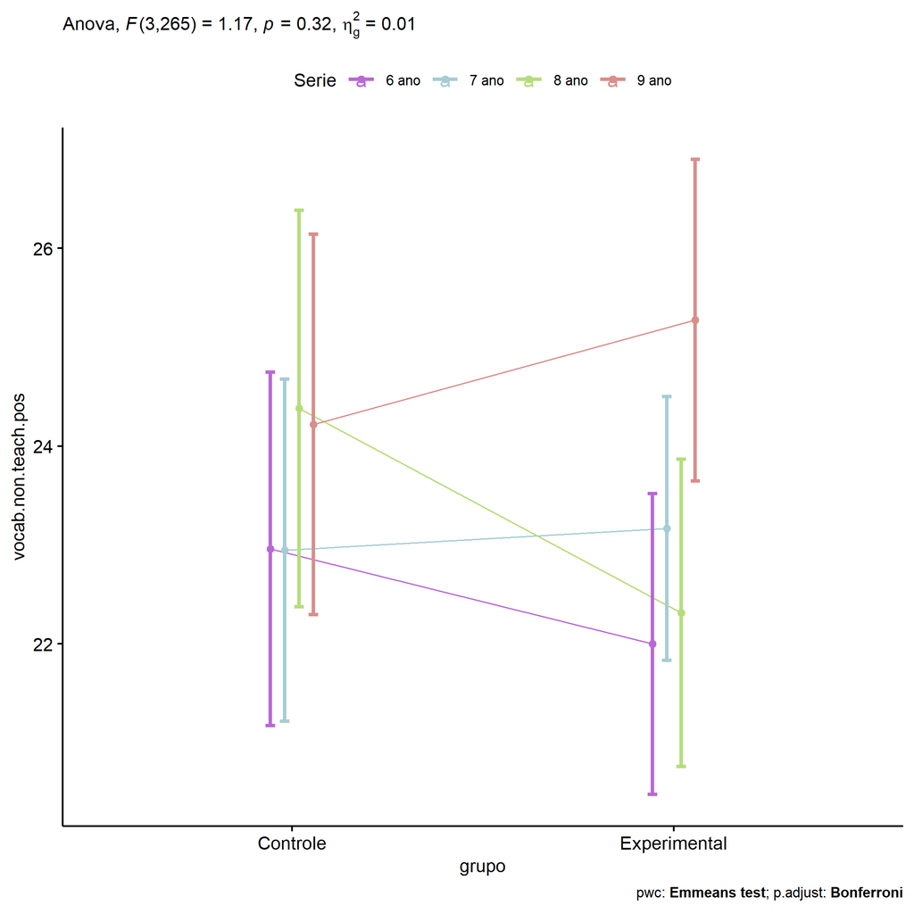

```r
if (!is.null(plots[["grupo"]]))
  plots[["grupo"]] + ggplot2::scale_color_manual(values = color[["Serie"]])
```

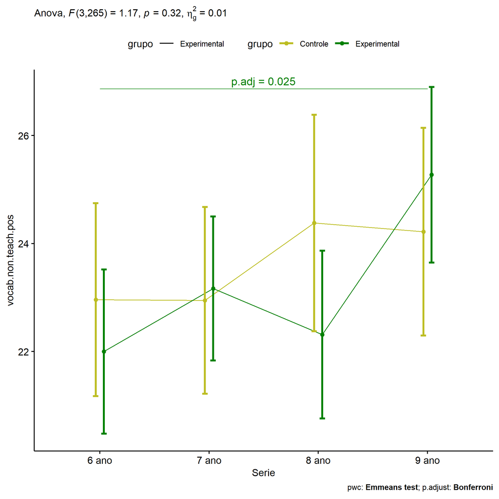

```r
if (!is.null(plots[["Serie"]]))
  plots[["Serie"]] + ggplot2::scale_color_manual(values = color[["grupo"]])
```

```r
plots <- twoWayAncovaBoxPlots(
  wdat, "vocab.non.teach.pos", c("grupo","Serie"), aov, pwcs, covar = "vocab.non.teach.pre",
  theme = "classic", color = color[["grupo:Serie"]],
  subtitle = which(aov$Effect == "grupo:Serie"))
```

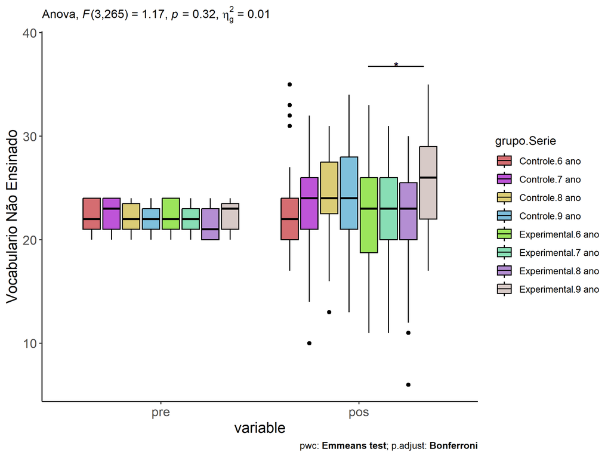

```r
plots[["grupo:Serie"]] + ggplot2::ylab("Vocabulario Não Ensinado") + ggplot2::scale_x_discrete(labels=c('pre', 'pos'))
```

```r
plots <- twoWayAncovaBoxPlots(
  wdat.long, "vocab.non.teach", c("grupo","Serie"), aov, pwc.long, pre.post = "time",
  theme = "classic", color = color$prepost)
```

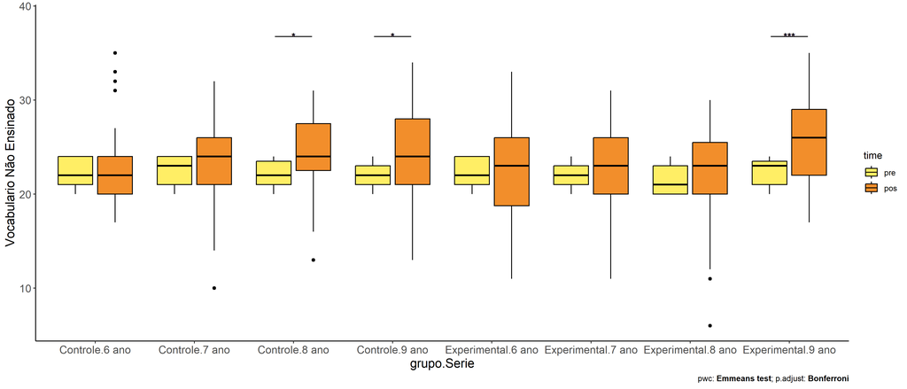

```r
plots[["grupo:Serie"]] + ggplot2::ylab("Vocabulario Não Ensinado")
```

### Checking linearity assumption

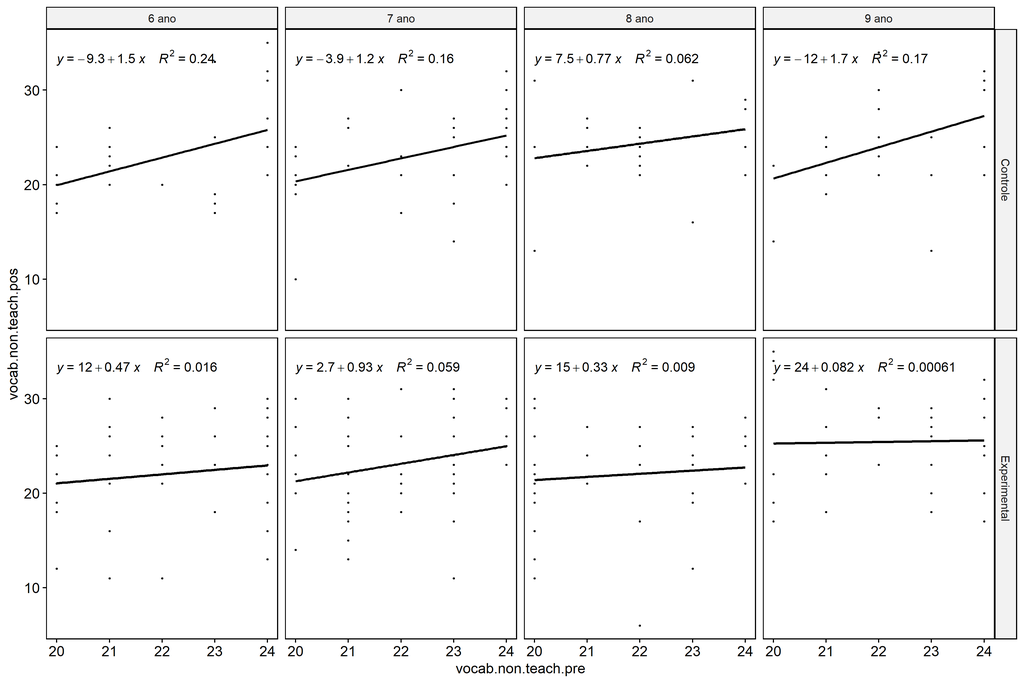

```r
ggscatter(wdat, x = "vocab.non.teach.pre", y = "vocab.non.teach.pos", size = 0.5,
          facet.by = c("grupo","Serie"), add = "reg.line")+
  stat_regline_equation(
    aes(label =  paste(..eq.label.., ..rr.label.., sep = "~~~~"))
  )
```

### Checking normality and homogeneity

```r
res <- augment(lm(vocab.non.teach.pos ~ vocab.non.teach.pre + grupo*Serie, data = wdat))
```

```r
shapiro_test(res$.resid)
```

```
## # A tibble: 1 × 3
##   variable   statistic p.value
##   <chr>          <dbl>   <dbl>
## 1 res$.resid     0.990  0.0616
```

```r
levene_test(res, .resid ~ grupo*Serie)
```

```
## # A tibble: 1 × 4
##     df1   df2 statistic     p
##   <int> <int>     <dbl> <dbl>
## 1     7   266     0.951 0.467
```

# Summary of Results

## Descriptive Statistics

```r
df <- get.descriptives(ldat[["grupo"]], c(dv.pre, dv.pos), c("grupo"),
                       include.global = T, symmetry.test = T, normality.test = F)
df <- plyr::rbind.fill(
  df, do.call(plyr::rbind.fill, lapply(lfatores2, FUN = function(f) {
    if (nrow(dat) > 0 && sum(!is.na(unique(dat[[f]]))) > 1)
      get.descriptives(ldat[[paste0("grupo:",f)]], c(dv.pre,dv.pos), c("grupo", f),
                       symmetry.test = T, normality.test = F)
    }))
)
(df <- df[,c(fatores1[fatores1 %in% colnames(df)],"variable",
             colnames(df)[!colnames(df) %in% c(fatores1,"variable")])])
```

```
##           grupo Sexo   Zona Cor.Raca Serie            variable   n   mean median min max    sd    se
## 1      Controle <NA>   <NA>     <NA>  <NA> vocab.non.teach.pre 108 22.185   22.0  20  24 1.454 0.140
## 2  Experimental <NA>   <NA>     <NA>  <NA> vocab.non.teach.pre 165 21.982   22.0  20  24 1.446 0.113
## 3          <NA> <NA>   <NA>     <NA>  <NA> vocab.non.teach.pre 273 22.062   22.0  20  24 1.450 0.088
## 4      Controle <NA>   <NA>     <NA>  <NA> vocab.non.teach.pos 108 23.648   24.0  10  35 4.715 0.454
## 5  Experimental <NA>   <NA>     <NA>  <NA> vocab.non.teach.pos 165 23.170   23.0  11  35 5.143 0.400
## 6          <NA> <NA>   <NA>     <NA>  <NA> vocab.non.teach.pos 273 23.359   24.0  10  35 4.975 0.301
## 7      Controle    F   <NA>     <NA>  <NA> vocab.non.teach.pre  63 22.143   22.0  20  24 1.490 0.188
## 8      Controle    M   <NA>     <NA>  <NA> vocab.non.teach.pre  45 22.244   22.0  20  24 1.417 0.211
## 9  Experimental    F   <NA>     <NA>  <NA> vocab.non.teach.pre  90 21.956   22.0  20  24 1.398 0.147
## 10 Experimental    M   <NA>     <NA>  <NA> vocab.non.teach.pre  76 22.013   22.0  20  24 1.501 0.172
## 11     Controle    F   <NA>     <NA>  <NA> vocab.non.teach.pos  63 24.413   24.0  14  35 4.383 0.552
## 12     Controle    M   <NA>     <NA>  <NA> vocab.non.teach.pos  45 22.578   23.0  10  33 4.998 0.745
## 13 Experimental    F   <NA>     <NA>  <NA> vocab.non.teach.pos  90 23.211   23.0   6  34 5.276 0.556
## 14 Experimental    M   <NA>     <NA>  <NA> vocab.non.teach.pos  76 22.895   23.0  11  35 5.353 0.614
```

[output cut: 87 more lines]

| grupo | Sexo | Zona | Cor.Raca | Serie | variable | n | mean | median | min | max | sd | se | ci | iqr | symmetry | skewness | kurtosis |
| --- | --- | --- | --- | --- | --- | --- | --- | --- | --- | --- | --- | --- | --- | --- | --- | --- | --- |
| Controle |  |  |  |  | vocab.non.teach.pre | 108 | 22.185 | 22.0 | 20 | 24 | 1.454 | 0.140 | 0.277 | 3.00 | YES | -0.140 | -1.357 |
| Experimental |  |  |  |  | vocab.non.teach.pre | 165 | 21.982 | 22.0 | 20 | 24 | 1.446 | 0.113 | 0.222 | 2.00 | YES | -0.029 | -1.413 |
|  |  |  |  |  | vocab.non.teach.pre | 273 | 22.062 | 22.0 | 20 | 24 | 1.450 | 0.088 | 0.173 | 2.00 | YES | -0.072 | -1.381 |
| Controle |  |  |  |  | vocab.non.teach.pos | 108 | 23.648 | 24.0 | 10 | 35 | 4.715 | 0.454 | 0.899 | 5.00 | YES | -0.074 | 0.162 |
| Experimental |  |  |  |  | vocab.non.teach.pos | 165 | 23.170 | 23.0 | 11 | 35 | 5.143 | 0.400 | 0.791 | 7.00 | YES | -0.351 | -0.222 |
|  |  |  |  |  | vocab.non.teach.pos | 273 | 23.359 | 24.0 | 10 | 35 | 4.975 | 0.301 | 0.593 | 6.00 | YES | -0.271 | -0.030 |
| Controle | F |  |  |  | vocab.non.teach.pre | 63 | 22.143 | 22.0 | 20 | 24 | 1.490 | 0.188 | 0.375 | 3.00 | YES | -0.068 | -1.423 |
| Controle | M |  |  |  | vocab.non.teach.pre | 45 | 22.244 | 22.0 | 20 | 24 | 1.417 | 0.211 | 0.426 | 2.00 | YES | -0.238 | -1.318 |
| Experimental | F |  |  |  | vocab.non.teach.pre | 90 | 21.956 | 22.0 | 20 | 24 | 1.398 | 0.147 | 0.293 | 2.00 | YES | -0.044 | -1.351 |
| Experimental | M |  |  |  | vocab.non.teach.pre | 76 | 22.013 | 22.0 | 20 | 24 | 1.501 | 0.172 | 0.343 | 2.00 | YES | -0.022 | -1.504 |
| Controle | F |  |  |  | vocab.non.teach.pos | 63 | 24.413 | 24.0 | 14 | 35 | 4.383 | 0.552 | 1.104 | 6.00 | YES | 0.234 | -0.141 |
| Controle | M |  |  |  | vocab.non.teach.pos | 45 | 22.578 | 23.0 | 10 | 33 | 4.998 | 0.745 | 1.501 | 5.00 | YES | -0.223 | -0.104 |
| Experimental | F |  |  |  | vocab.non.teach.pos | 90 | 23.211 | 23.0 | 6 | 34 | 5.276 | 0.556 | 1.105 | 7.00 | NO | -0.500 | 0.343 |
| Experimental | M |  |  |  | vocab.non.teach.pos | 76 | 22.895 | 23.0 | 11 | 35 | 5.353 | 0.614 | 1.223 | 6.25 | YES | -0.416 | -0.290 |
| Controle |  | Rural |  |  | vocab.non.teach.pre | 61 | 22.426 | 23.0 | 20 | 24 | 1.372 | 0.176 | 0.351 | 2.00 | YES | -0.401 | -1.063 |
| Controle |  | Urbana |  |  | vocab.non.teach.pre | 19 | 21.684 | 21.0 | 20 | 24 | 1.416 | 0.325 | 0.683 | 2.00 | YES | 0.422 | -1.312 |
| Experimental |  | Rural |  |  | vocab.non.teach.pre | 77 | 22.052 | 22.0 | 20 | 24 | 1.503 | 0.171 | 0.341 | 2.00 | YES | -0.041 | -1.466 |
| Experimental |  | Urbana |  |  | vocab.non.teach.pre | 44 | 22.068 | 22.0 | 20 | 24 | 1.388 | 0.209 | 0.422 | 2.00 | YES | -0.170 | -1.369 |
| Controle |  | Rural |  |  | vocab.non.teach.pos | 61 | 24.344 | 24.0 | 13 | 35 | 4.622 | 0.592 | 1.184 | 6.00 | YES | 0.159 | -0.346 |
| Controle |  | Urbana |  |  | vocab.non.teach.pos | 19 | 23.053 | 24.0 | 14 | 30 | 3.659 | 0.839 | 1.763 | 4.50 | NO | -0.536 | 0.107 |
| Experimental |  | Rural |  |  | vocab.non.teach.pos | 77 | 23.390 | 24.0 | 11 | 34 | 5.148 | 0.587 | 1.169 | 6.00 | YES | -0.330 | -0.331 |
| Experimental |  | Urbana |  |  | vocab.non.teach.pos | 44 | 23.000 | 24.0 | 11 | 30 | 5.144 | 0.776 | 1.564 | 7.00 | NO | -0.758 | -0.263 |
| Controle |  |  | Branca |  | vocab.non.teach.pre | 17 | 22.118 | 22.0 | 20 | 24 | 1.576 | 0.382 | 0.811 | 3.00 | YES | -0.091 | -1.595 |
| Controle |  |  | Indígena |  | vocab.non.teach.pre | 6 | 21.833 | 21.5 | 20 | 24 | 2.041 | 0.833 | 2.142 | 3.75 | few data | 0.000 | 0.000 |
| Controle |  |  | Parda |  | vocab.non.teach.pre | 29 | 21.862 | 22.0 | 20 | 24 | 1.457 | 0.271 | 0.554 | 2.00 | YES | 0.097 | -1.455 |
| Experimental |  |  | Branca |  | vocab.non.teach.pre | 17 | 22.588 | 23.0 | 20 | 24 | 1.372 | 0.333 | 0.705 | 3.00 | YES | -0.378 | -1.431 |
| Experimental |  |  | Indígena |  | vocab.non.teach.pre | 5 | 21.400 | 21.0 | 20 | 24 | 1.673 | 0.748 | 2.078 | 2.00 | NO | 0.522 | -1.634 |
| Experimental |  |  | Parda |  | vocab.non.teach.pre | 41 | 22.073 | 22.0 | 20 | 24 | 1.506 | 0.235 | 0.476 | 2.00 | YES | -0.164 | -1.471 |
| Controle |  |  | Branca |  | vocab.non.teach.pos | 17 | 22.588 | 23.0 | 17 | 32 | 4.473 | 1.085 | 2.300 | 6.00 | NO | 0.501 | -0.781 |
| Controle |  |  | Indígena |  | vocab.non.teach.pos | 6 | 24.667 | 23.5 | 21 | 32 | 4.227 | 1.726 | 4.436 | 4.75 | NO | 0.670 | -1.282 |
| Controle |  |  | Parda |  | vocab.non.teach.pos | 29 | 23.793 | 24.0 | 10 | 31 | 5.434 | 1.009 | 2.067 | 6.00 | NO | -0.728 | 0.087 |
| Experimental |  |  | Branca |  | vocab.non.teach.pos | 17 | 21.647 | 23.0 | 12 | 32 | 6.284 | 1.524 | 3.231 | 10.00 | YES | -0.242 | -1.386 |
| Experimental |  |  | Indígena |  | vocab.non.teach.pos | 5 | 25.400 | 28.0 | 18 | 30 | 5.177 | 2.315 | 6.428 | 7.00 | YES | -0.408 | -1.944 |
| Experimental |  |  | Parda |  | vocab.non.teach.pos | 41 | 23.829 | 24.0 | 11 | 34 | 4.727 | 0.738 | 1.492 | 5.00 | YES | -0.418 | 0.288 |
| Controle |  |  |  | 6 ano | vocab.non.teach.pre | 29 | 22.069 | 22.0 | 20 | 24 | 1.602 | 0.297 | 0.609 | 3.00 | YES | -0.058 | -1.682 |
| Controle |  |  |  | 7 ano | vocab.non.teach.pre | 31 | 22.290 | 23.0 | 20 | 24 | 1.553 | 0.279 | 0.570 | 3.00 | YES | -0.368 | -1.449 |
| Controle |  |  |  | 8 ano | vocab.non.teach.pre | 23 | 22.130 | 22.0 | 20 | 24 | 1.392 | 0.290 | 0.602 | 2.50 | YES | 0.069 | -1.326 |
| Controle |  |  |  | 9 ano | vocab.non.teach.pre | 25 | 22.240 | 22.0 | 20 | 24 | 1.268 | 0.254 | 0.523 | 2.00 | YES | 0.037 | -1.129 |
| Experimental |  |  |  | 6 ano | vocab.non.teach.pre | 40 | 22.125 | 22.0 | 20 | 24 | 1.539 | 0.243 | 0.492 | 3.00 | YES | -0.039 | -1.542 |
| Experimental |  |  |  | 7 ano | vocab.non.teach.pre | 52 | 22.019 | 22.0 | 20 | 24 | 1.276 | 0.177 | 0.355 | 2.00 | YES | -0.091 | -1.260 |
| Experimental |  |  |  | 8 ano | vocab.non.teach.pre | 39 | 21.538 | 21.0 | 20 | 24 | 1.466 | 0.235 | 0.475 | 3.00 | YES | 0.268 | -1.487 |
| Experimental |  |  |  | 9 ano | vocab.non.teach.pre | 35 | 22.257 | 23.0 | 20 | 24 | 1.482 | 0.251 | 0.509 | 2.50 | YES | -0.274 | -1.465 |
| Controle |  |  |  | 6 ano | vocab.non.teach.pos | 29 | 22.966 | 22.0 | 17 | 35 | 4.822 | 0.895 | 1.834 | 4.00 | NO | 0.945 | 0.032 |
| Controle |  |  |  | 7 ano | vocab.non.teach.pos | 31 | 23.129 | 24.0 | 10 | 32 | 4.653 | 0.836 | 1.707 | 5.00 | NO | -0.590 | 0.540 |
| Controle |  |  |  | 8 ano | vocab.non.teach.pos | 23 | 24.435 | 24.0 | 13 | 31 | 4.294 | 0.895 | 1.857 | 5.00 | NO | -0.734 | 0.513 |
| Controle |  |  |  | 9 ano | vocab.non.teach.pos | 25 | 24.360 | 24.0 | 13 | 34 | 5.098 | 1.020 | 2.104 | 7.00 | YES | -0.205 | -0.232 |
| Experimental |  |  |  | 6 ano | vocab.non.teach.pos | 40 | 22.050 | 23.0 | 11 | 33 | 5.773 | 0.913 | 1.846 | 7.25 | YES | -0.382 | -0.778 |
| Experimental |  |  |  | 7 ano | vocab.non.teach.pos | 52 | 23.135 | 23.0 | 11 | 31 | 4.883 | 0.677 | 1.359 | 6.00 | YES | -0.293 | -0.498 |
| Experimental |  |  |  | 8 ano | vocab.non.teach.pos | 39 | 21.897 | 23.0 | 6 | 30 | 5.134 | 0.822 | 1.664 | 5.50 | NO | -1.060 | 0.988 |
| Experimental |  |  |  | 9 ano | vocab.non.teach.pos | 35 | 25.429 | 26.0 | 17 | 35 | 4.919 | 0.831 | 1.690 | 7.00 | YES | -0.035 | -1.029 |

## ANCOVA Table Comparison

```r
df <- do.call(plyr::rbind.fill, laov)
(df <- df[!duplicated(df$Effect),])
```

```
##                 Effect DFn DFd      F        p p<.05      ges DFn' DFd'        F'       p' p<.05'
## 1                grupo   1 270  0.261 6.10e-01       0.000966    1  274  0.145000 0.704000
## 2  vocab.non.teach.pre   1 270 17.435 4.02e-05     * 0.061000    1  274 13.701000 0.000259      *
## 4           grupo:Sexo   1 269  1.607 2.06e-01       0.006000    1  272  0.321000 0.572000
## 5                 Sexo   1 269  2.631 1.06e-01       0.010000    1  272  2.145000 0.144000
## 8           grupo:Zona   1 196  0.026 8.72e-01       0.000133    1  197  0.000591 0.981000
## 10                Zona   1 196  0.449 5.03e-01       0.002000    1  197  0.273000 0.602000
## 11            Cor.Raca   2 108  3.595 3.10e-02     * 0.062000    2  110  2.171000 0.119000
## 13      grupo:Cor.Raca   2 108  0.435 6.49e-01       0.008000    2  110  0.320000 0.727000
## 16         grupo:Serie   3 265  1.169 3.22e-01       0.013000    3  268  0.260000 0.854000
## 17               Serie   3 265  2.815 4.00e-02     * 0.031000    3  268  1.941000 0.123000
##        ges'
## 1  0.000529
## 2  0.048000
## 4  0.001000
## 5  0.008000
## 8  0.000003
## 10 0.001000
## 11 0.038000
## 13 0.006000
## 16 0.003000
## 17 0.021000
```

|  | Effect | DFn | DFd | F | p | p<.05 | ges | DFn’ | DFd’ | F’ | p’ | p<.05’ | ges’ |
| --- | --- | --- | --- | --- | --- | --- | --- | --- | --- | --- | --- | --- | --- |
| 1 | grupo | 1 | 270 | 0.261 | 0.610 |  | 0.001 | 1 | 274 | 0.145 | 0.704 |  | 0.001 |
| 2 | vocab.non.teach.pre | 1 | 270 | 17.435 | 0.000 | * | 0.061 | 1 | 274 | 13.701 | 0.000 | * | 0.048 |
| 4 | grupo:Sexo | 1 | 269 | 1.607 | 0.206 |  | 0.006 | 1 | 272 | 0.321 | 0.572 |  | 0.001 |
| 5 | Sexo | 1 | 269 | 2.631 | 0.106 |  | 0.010 | 1 | 272 | 2.145 | 0.144 |  | 0.008 |
| 8 | grupo:Zona | 1 | 196 | 0.026 | 0.872 |  | 0.000 | 1 | 197 | 0.001 | 0.981 |  | 0.000 |
| 10 | Zona | 1 | 196 | 0.449 | 0.503 |  | 0.002 | 1 | 197 | 0.273 | 0.602 |  | 0.001 |
| 11 | Cor.Raca | 2 | 108 | 3.595 | 0.031 | * | 0.062 | 2 | 110 | 2.171 | 0.119 |  | 0.038 |
| 13 | grupo:Cor.Raca | 2 | 108 | 0.435 | 0.649 |  | 0.008 | 2 | 110 | 0.320 | 0.727 |  | 0.006 |
| 16 | grupo:Serie | 3 | 265 | 1.169 | 0.322 |  | 0.013 | 3 | 268 | 0.260 | 0.854 |  | 0.003 |
| 17 | Serie | 3 | 265 | 2.815 | 0.040 | * | 0.031 | 3 | 268 | 1.941 | 0.123 |  | 0.021 |

## PairWise Table Comparison

```r
df <- do.call(plyr::rbind.fill, lpwc)
df <- df[,c(names(lfatores), names(df)[!names(df) %in% c(names(lfatores),"term",".y.")])]
```

| grupo | Sexo | Zona | Cor.Raca | Serie | group1 | group2 | df | statistic | p | p.adj | p.adj.signif | df’ | statistic’ | p’ | p.adj’ | p.adj.signif’ |
| --- | --- | --- | --- | --- | --- | --- | --- | --- | --- | --- | --- | --- | --- | --- | --- | --- |
| Controle |  |  |  |  | pre | pos | 542 | -2.932 | 0.004 | 0.004 | ** | 550 | -2.187 | 0.029 | 0.029 | * |
| Experimental |  |  |  |  | pre | pos | 542 | -2.943 | 0.003 | 0.003 | ** | 550 | -2.205 | 0.028 | 0.028 | * |
|  |  |  |  |  | Controle | Experimental | 270 | 0.511 | 0.610 | 0.610 | ns | 274 | 0.381 | 0.704 | 0.704 | ns |
| Controle | F |  |  |  | pre | pos | 540 | -3.422 | 0.001 | 0.001 | *** | 546 | -2.511 | 0.012 | 0.012 | * |
| Controle | M |  |  |  | pre | pos | 540 | -0.425 | 0.671 | 0.671 | ns | 546 | -0.401 | 0.689 | 0.689 | ns |
| Controle |  |  |  |  | F | M | 269 | 2.003 | 0.046 | 0.046 | * | 272 | 1.357 | 0.176 | 0.176 | ns |
| Experimental | F |  |  |  | pre | pos | 540 | -2.262 | 0.024 | 0.024 | * | 546 | -2.134 | 0.033 | 0.033 | * |
| Experimental | M |  |  |  | pre | pos | 540 | -1.460 | 0.145 | 0.145 | ns | 546 | -0.939 | 0.348 | 0.348 | ns |
| Experimental |  |  |  |  | F | M | 269 | 0.477 | 0.633 | 0.633 | ns | 272 | 0.790 | 0.430 | 0.430 | ns |
|  | F |  |  |  | Controle | Experimental | 269 | 1.288 | 0.199 | 0.199 | ns | 272 | 0.599 | 0.549 | 0.549 | ns |
|  | M |  |  |  | Controle | Experimental | 269 | -0.556 | 0.579 | 0.579 | ns | 272 | -0.229 | 0.819 | 0.819 | ns |
| Controle |  |  |  |  | Rural | Urbana | 196 | 0.520 | 0.603 | 0.603 | ns | 197 | 0.284 | 0.777 | 0.777 | ns |
| Controle |  | Rural |  |  | pre | pos | 394 | -2.950 | 0.003 | 0.003 | ** | 396 | -2.486 | 0.013 | 0.013 | * |
| Controle |  | Urbana |  |  | pre | pos | 394 | -1.175 | 0.241 | 0.241 | ns | 396 | -1.145 | 0.253 | 0.253 | ns |
| Experimental |  |  |  |  | Rural | Urbana | 196 | 0.452 | 0.652 | 0.652 | ns | 197 | 0.439 | 0.661 | 0.661 | ns |
| Experimental |  | Rural |  |  | pre | pos | 394 | -2.312 | 0.021 | 0.021 | * | 396 | -2.253 | 0.025 | 0.025 | * |
| Experimental |  | Urbana |  |  | pre | pos | 394 | -1.217 | 0.224 | 0.224 | ns | 396 | -1.186 | 0.236 | 0.236 | ns |
|  |  | Rural |  |  | Controle | Experimental | 196 | 0.776 | 0.439 | 0.439 | ns | 197 | 0.422 | 0.674 | 0.674 | ns |
|  |  | Urbana |  |  | Controle | Experimental | 196 | 0.295 | 0.768 | 0.768 | ns | 197 | 0.292 | 0.771 | 0.771 | ns |
| Controle |  |  | Branca |  | pre | pos | 218 | -0.363 | 0.717 | 0.717 | ns | 222 | -0.329 | 0.742 | 0.742 | ns |
| Controle |  |  | Indígena |  | pre | pos | 218 | -1.297 | 0.196 | 0.196 | ns | 222 | -1.177 | 0.240 | 0.240 | ns |
| Controle |  |  |  |  | Branca | Indígena | 108 | -1.090 | 0.278 | 0.835 | ns | 110 | -0.944 | 0.347 | 1.000 | ns |
| Controle |  |  |  |  | Branca | Parda | 108 | -1.064 | 0.290 | 0.869 | ns | 110 | -0.580 | 0.563 | 1.000 | ns |
| Controle |  |  |  |  | Indígena | Parda | 108 | 0.429 | 0.669 | 1.000 | ns | 110 | 0.609 | 0.544 | 1.000 | ns |
| Controle |  |  | Parda |  | pre | pos | 218 | -1.943 | 0.053 | 0.053 | ns | 222 | -1.269 | 0.206 | 0.206 | ns |
| Experimental |  |  | Branca |  | pre | pos | 218 | 0.725 | 0.469 | 0.469 | ns | 222 | 0.658 | 0.511 | 0.511 | ns |
| Experimental |  |  | Indígena |  | pre | pos | 218 | -1.671 | 0.096 | 0.096 | ns | 222 | -1.517 | 0.131 | 0.131 | ns |
| Experimental |  |  |  |  | Branca | Indígena | 108 | -2.185 | 0.031 | 0.093 | ns | 110 | -1.875 | 0.063 | 0.190 | ns |
| Experimental |  |  |  |  | Branca | Parda | 108 | -2.081 | 0.040 | 0.119 | ns | 110 | -1.451 | 0.150 | 0.449 | ns |
| Experimental |  |  |  |  | Indígena | Parda | 108 | 1.092 | 0.277 | 0.832 | ns | 110 | 1.146 | 0.254 | 0.762 | ns |
| Experimental |  |  | Parda |  | pre | pos | 218 | -2.101 | 0.037 | 0.037 | * | 222 | -1.335 | 0.183 | 0.183 | ns |
|  |  |  | Branca |  | Controle | Experimental | 108 | 0.959 | 0.340 | 0.340 | ns | 110 | 0.816 | 0.416 | 0.416 | ns |
|  |  |  | Indígena |  | Controle | Experimental | 108 | -0.455 | 0.650 | 0.650 | ns | 110 | -0.386 | 0.700 | 0.700 | ns |
|  |  |  | Parda |  | Controle | Experimental | 108 | 0.211 | 0.833 | 0.833 | ns | 110 | 0.159 | 0.874 | 0.874 | ns |
| Controle |  |  |  | 6 ano | pre | pos | 532 | -0.926 | 0.355 | 0.355 | ns | 538 | -0.868 | 0.386 | 0.386 | ns |
| Controle |  |  |  | 7 ano | pre | pos | 532 | -0.896 | 0.371 | 0.371 | ns | 538 | -0.840 | 0.401 | 0.401 | ns |
| Controle |  |  |  | 8 ano | pre | pos | 532 | -2.120 | 0.034 | 0.034 | * | 538 | -0.827 | 0.409 | 0.409 | ns |
| Controle |  |  |  | 9 ano | pre | pos | 532 | -2.034 | 0.042 | 0.042 | * | 538 | -1.906 | 0.057 | 0.057 | ns |
| Controle |  |  |  |  | 6 ano | 7 ano | 265 | 0.010 | 0.992 | 1.000 | ns | 268 | 0.005 | 0.996 | 1.000 | ns |
| Controle |  |  |  |  | 6 ano | 8 ano | 265 | -1.042 | 0.298 | 1.000 | ns | 268 | -0.024 | 0.981 | 1.000 | ns |
| Controle |  |  |  |  | 6 ano | 9 ano | 265 | -0.944 | 0.346 | 1.000 | ns | 268 | -0.878 | 0.381 | 1.000 | ns |
| Controle |  |  |  |  | 7 ano | 8 ano | 265 | -1.066 | 0.287 | 1.000 | ns | 268 | -0.030 | 0.976 | 1.000 | ns |
| Controle |  |  |  |  | 7 ano | 9 ano | 265 | -0.968 | 0.334 | 1.000 | ns | 268 | -0.897 | 0.370 | 1.000 | ns |
| Controle |  |  |  |  | 8 ano | 9 ano | 265 | 0.115 | 0.909 | 1.000 | ns | 268 | -0.824 | 0.411 | 1.000 | ns |
| Experimental |  |  |  | 6 ano | pre | pos | 532 | 0.091 | 0.928 | 0.928 | ns | 538 | 0.085 | 0.932 | 0.932 | ns |
| Experimental |  |  |  | 7 ano | pre | pos | 532 | -1.543 | 0.123 | 0.123 | ns | 538 | -1.446 | 0.149 | 0.149 | ns |
| Experimental |  |  |  | 8 ano | pre | pos | 532 | -0.430 | 0.667 | 0.667 | ns | 538 | -0.403 | 0.687 | 0.687 | ns |
| Experimental |  |  |  | 9 ano | pre | pos | 532 | -3.600 | 0.000 | 0.000 | *** | 538 | -2.697 | 0.007 | 0.007 | ** |
| Experimental |  |  |  |  | 6 ano | 7 ano | 265 | -1.138 | 0.256 | 1.000 | ns | 268 | -1.053 | 0.293 | 1.000 | ns |
| Experimental |  |  |  |  | 6 ano | 8 ano | 265 | -0.284 | 0.776 | 1.000 | ns | 268 | -0.252 | 0.801 | 1.000 | ns |
| Experimental |  |  |  |  | 6 ano | 9 ano | 265 | -2.896 | 0.004 | 0.025 | * | 268 | -2.157 | 0.032 | 0.192 | ns |
| Experimental |  |  |  |  | 7 ano | 8 ano | 265 | 0.823 | 0.412 | 1.000 | ns | 268 | 0.773 | 0.440 | 1.000 | ns |
| Experimental |  |  |  |  | 7 ano | 9 ano | 265 | -1.969 | 0.050 | 0.300 | ns | 268 | -1.263 | 0.208 | 1.000 | ns |
| Experimental |  |  |  |  | 8 ano | 9 ano | 265 | -2.581 | 0.010 | 0.062 | ns | 268 | -1.881 | 0.061 | 0.367 | ns |
|  |  |  |  | 6 ano | Controle | Experimental | 265 | 0.806 | 0.421 | 0.421 | ns | 268 | 0.747 | 0.456 | 0.456 | ns |
|  |  |  |  | 7 ano | Controle | Experimental | 265 | -0.199 | 0.842 | 0.842 | ns | 268 | -0.180 | 0.858 | 0.858 | ns |
|  |  |  |  | 8 ano | Controle | Experimental | 265 | 1.602 | 0.110 | 0.110 | ns | 268 | 0.512 | 0.609 | 0.609 | ns |
|  |  |  |  | 9 ano | Controle | Experimental | 265 | -0.825 | 0.410 | 0.410 | ns | 268 | -0.283 | 0.777 | 0.777 | ns |

## EMMS Table Comparison

```r
df <- do.call(plyr::rbind.fill, lemms)
df[["N-N'"]] <- df[["N"]] - df[["N'"]]
df <- df[,c(names(lfatores), names(df)[!names(df) %in% names(lfatores)])]
```

| grupo | Sexo | Zona | Cor.Raca | Serie | N | M (pre) | SE (pre) | M (unadj) | SE (unadj) | M (adj) | SE (adj) | N’ | M (pre)’ | SE (pre)’ | M (unadj)’ | SE (unadj)’ | M (adj)’ | SE (adj)’ | N-N’ |
| --- | --- | --- | --- | --- | --- | --- | --- | --- | --- | --- | --- | --- | --- | --- | --- | --- | --- | --- | --- |
| Controle |  |  |  |  | 108 | 22.185 | 0.140 | 23.648 | 0.454 | 23.544 | 0.466 | 110 | 22.182 | 0.137 | 23.345 | 0.494 | 23.250 | 0.503 | -2 |
| Experimental |  |  |  |  | 165 | 21.982 | 0.113 | 23.170 | 0.400 | 23.238 | 0.377 | 167 | 21.988 | 0.111 | 22.940 | 0.428 | 23.003 | 0.408 | -2 |
| Controle | F |  |  |  | 63 | 22.143 | 0.188 | 24.413 | 0.552 | 24.344 | 0.620 | 65 | 22.138 | 0.182 | 23.877 | 0.654 | 23.816 | 0.653 | -2 |
| Controle | M |  |  |  | 45 | 22.244 | 0.211 | 22.578 | 0.745 | 22.422 | 0.734 | 45 | 22.244 | 0.211 | 22.578 | 0.745 | 22.429 | 0.786 | 0 |
| Experimental | F |  |  |  | 90 | 21.956 | 0.147 | 23.211 | 0.556 | 23.302 | 0.519 | 90 | 21.956 | 0.147 | 23.211 | 0.556 | 23.302 | 0.556 | 0 |
| Experimental | M |  |  |  | 76 | 22.013 | 0.172 | 22.895 | 0.614 | 22.937 | 0.564 | 77 | 22.026 | 0.170 | 22.623 | 0.664 | 22.656 | 0.600 | -1 |
| Controle |  | Rural |  |  | 61 | 22.426 | 0.176 | 24.344 | 0.592 | 24.093 | 0.609 | 62 | 22.419 | 0.173 | 24.065 | 0.646 | 23.813 | 0.621 | -1 |
| Controle |  | Urbana |  |  | 19 | 21.684 | 0.325 | 23.053 | 0.839 | 23.441 | 1.089 | 19 | 21.684 | 0.325 | 23.053 | 0.839 | 23.448 | 1.121 | 0 |
| Experimental |  | Rural |  |  | 77 | 22.052 | 0.171 | 23.390 | 0.587 | 23.461 | 0.539 | 77 | 22.052 | 0.171 | 23.390 | 0.587 | 23.461 | 0.555 | 0 |
| Experimental |  | Urbana |  |  | 44 | 22.068 | 0.209 | 23.000 | 0.776 | 23.057 | 0.712 | 44 | 22.068 | 0.209 | 23.000 | 0.776 | 23.058 | 0.733 | 0 |
| Controle |  |  | Branca |  | 17 | 22.118 | 0.382 | 22.588 | 1.085 | 22.513 | 1.150 | 17 | 22.118 | 0.382 | 22.588 | 1.085 | 22.527 | 1.313 | 0 |
| Controle |  |  | Indígena |  | 6 | 21.833 | 0.833 | 24.667 | 1.726 | 24.968 | 1.936 | 6 | 21.833 | 0.833 | 24.667 | 1.726 | 24.956 | 2.211 | 0 |
| Controle |  |  | Parda |  | 29 | 21.862 | 0.271 | 23.793 | 1.009 | 24.056 | 0.882 | 30 | 21.867 | 0.261 | 23.233 | 1.124 | 23.482 | 0.991 | -1 |
| Experimental |  |  | Branca |  | 17 | 22.588 | 0.333 | 21.647 | 1.524 | 20.949 | 1.160 | 17 | 22.588 | 0.333 | 21.647 | 1.524 | 21.006 | 1.325 | 0 |
| Experimental |  |  | Indígena |  | 5 | 21.400 | 0.748 | 25.400 | 2.315 | 26.275 | 2.129 | 5 | 21.400 | 0.748 | 25.400 | 2.315 | 26.224 | 2.431 | 0 |
| Experimental |  |  | Parda |  | 41 | 22.073 | 0.235 | 23.829 | 0.738 | 23.813 | 0.740 | 42 | 22.095 | 0.231 | 23.310 | 0.888 | 23.276 | 0.835 | -1 |
| Controle |  |  |  | 6 ano | 29 | 22.069 | 0.297 | 22.966 | 0.895 | 22.960 | 0.907 | 29 | 22.069 | 0.297 | 22.966 | 0.895 | 22.962 | 0.978 | 0 |
| Controle |  |  |  | 7 ano | 31 | 22.290 | 0.279 | 23.129 | 0.836 | 22.947 | 0.878 | 31 | 22.290 | 0.279 | 23.129 | 0.836 | 22.955 | 0.947 | 0 |
| Controle |  |  |  | 8 ano | 23 | 22.130 | 0.290 | 24.435 | 0.895 | 24.380 | 1.018 | 25 | 22.120 | 0.267 | 23.040 | 1.268 | 22.998 | 1.053 | -2 |
| Controle |  |  |  | 9 ano | 25 | 22.240 | 0.254 | 24.360 | 1.020 | 24.218 | 0.977 | 25 | 22.240 | 0.254 | 24.360 | 1.020 | 24.225 | 1.054 | 0 |
| Experimental |  |  |  | 6 ano | 40 | 22.125 | 0.243 | 22.050 | 0.913 | 22.000 | 0.772 | 40 | 22.125 | 0.243 | 22.050 | 0.913 | 22.004 | 0.833 | 0 |
| Experimental |  |  |  | 7 ano | 52 | 22.019 | 0.177 | 23.135 | 0.677 | 23.169 | 0.677 | 52 | 22.019 | 0.177 | 23.135 | 0.677 | 23.170 | 0.730 | 0 |
| Experimental |  |  |  | 8 ano | 39 | 21.538 | 0.235 | 21.897 | 0.822 | 22.314 | 0.789 | 39 | 21.538 | 0.235 | 21.897 | 0.822 | 22.304 | 0.851 | 0 |
| Experimental |  |  |  | 9 ano | 35 | 22.257 | 0.251 | 25.429 | 0.831 | 25.273 | 0.826 | 36 | 22.278 | 0.244 | 24.778 | 1.037 | 24.613 | 0.879 | -1 |